# Business Statistics End-Term Assessment IB94X0 2022-2023 #2

2247946

2022-12-10

[figure not shown]

# Masters Programmes

## Assignment Cover Sheet

Submitted by : 2247946  
Date Sent : 2023-01-16  
Module Title : Business Statistics  
Module Code : IB94X0  
Date/Year of Module : Term One 2022-2023  
Submission Deadline : Monday, 16th January 2023 (12:00 UK Time)  
Word Count : Approximately (2500 words) Number of Pages : 1 HTML Pages  
Question : Business Statistics (IB94X0) - Individual Assignment 2

“This is to certify that the work I am submitting is my own. All external references and sources are clearly acknowledged and identified within the contents. I am aware of the University of Warwick regulation concerning plagiarism and collusion.

No substantial part(s) of the work submitted here has also been submitted by me in other assessments for accredited courses of study, and I acknowledge that if this has been done an appropriate reduction in the mark I might otherwise have received will be made.”

“I declare that this work is entirely my own in accordance with the University’s Regulation 11 and the WBS guidelines on plagiarism and collusion. All external references and sources are clearly acknowledged and identified within the contents.

No substantial part(s) of the work submitted here has also been submitted by me in other assessments for accredited courses of study, and I acknowledge that if this has been done it may result in me being reported for self-plagiarism and an appropriate reduction in marks may be made when marking this piece of work.”

# Question 1

# The Scenario

The dataset comes from the Food Standards Agency. A panel of Food Standard Agency board and local politicians want to better understand whether employing more professional enforcement officers increases the likelihood of establishments successfully responding to enforcement actions.

The Food Standards Agency (FSA) is responsible for monitoring and reporting on the performance of local authority (LA) food law enforcement services in England, Wales and Northern Ireland. Data are collected annually from Local Authorities, on food law enforcement activity within food establishments.

The dataset covers the period 1 April 2019 to 31 March 2020 so provides a picture of local authority activity at the point the UK-wide lockdown to control the spread of COVID-19 began in late March 2020.

Description of each variable in the dataset are shown below.

| Variable | Description |
| --- | --- |
| Country | Country |
| LAType | LAType |
| LAName | LAName |
| Totalestablishments(includingnotyetrated&outside) | Number of Total establishments (including not yet rated & outside the programme) |
| Establishmentsnotyetratedforintervention | Number of Establishments not yet rated for intervention |
| Establishmentsoutsidetheprogramme | Establishments outside the programme |
| Total%ofBroadlyCompliantestablishmentsratedA-E | Total percentage of Broadly Compliant rated establishments |
| Total%ofBroadlyCompliantestablishments(includingnotyetrated) | Total percentage of Broadly Compliant rated establishments (including not yet rated establishments) |
| Aratedestablishments | Number of A-rated establishment |
| Total%ofBroadlyCompliantestablishments-A | Percentage of Broadly Compliant establishments rated A |
| Bratedestablishments | Number of B-rated establishment |
| Total%ofBroadlyCompliantestablishments-B | Percentage of Broadly Compliant establishments rated B |
| Cratedestablishments | Number of C-rated establishment |
| Total%ofBroadlyCompliantestablishments-C | Percentage of Broadly Compliant establishments rated C |
| Dratedestablishments | Number of D-rated establishment |
| Total%ofBroadlyCompliantestablishments-D | Percentage of Broadly Compliant establishments rated D |
| Eratedestablishments | Number of E-rated establishment |
| Total%ofBroadlyCompliantestablishments-E | Percentage of Broadly Compliant establishments rated E |
| Total%ofInterventionsachieved(premisesratedA-E) | Total percentage of Interventions achieved in rated establishments |
| Total%ofInterventionsachieved-premisesratedA | Percentage of Interventions achieved in establishments rated A |
| Total%ofInterventionsachieved-premisesratedB | Percentage of Interventions achieved in establishments rated B |
| Total%ofInterventionsachieved-premisesratedC | Percentage of Interventions achieved in establishments rated C |
| Total%ofInterventionsachieved-premisesratedD | Percentage of Interventions achieved in establishments rated D |
| Total%ofInterventionsachieved-premisesratedE | Percentage of Interventions achieved in establishments rated E |
| Total%ofInterventionsachieved-premisesnotyetrated | Percentage of Interventions achieved in establishments not yet rated |
| Totalnumberofestablishmentssubjecttoformalenforcementactions-Voluntaryclosure | Number of establishments subject to Voluntary closure |
| Totalnumberofestablishmentssubjecttoformalenforcementactions-Seizure,detention&surrenderoffood | Number of establishments subject to Seizure,Detention & Surrender of Food |
| Totalnumberofestablishmentssubjecttoformalenforcementactions-Suspension/revocationofapprovalorlicence | Number of establishments subject to Suspension / Revocation of Approval or Licence |
| Totalnumberofestablishmentssubjecttoformalenforcementactions-Hygieneemergencyprohibitionnotice | Number of establishments subject to Hygiene Emergency Prohibition Notice |
| Totalnumberofestablishmentssubjecttoformalenforcementactions-Prohibitionorder | Number of establishments subject to Prohibiton Order |
| Totalnumberofestablishmentssubjecttoformalenforcementactions-Simplecaution | Number of establishments subject to Simple Auction |
| Totalnumberofestablishmentssubjecttoformalenforcementactions-Hygieneimprovementnotices | Number of establishments subject to Hygiene Improvements Notices |
| Totalnumberofestablishmentssubjecttoformalenforcementactions-Remedialaction&detentionnotices | Number of establishments subject to Remedial Action & Detention Notices |
| TotalnumberofestablishmentssubjecttoWrittenwarnings | Number of establishments subject to Written Warnings |
| Totalnumberofestablishmentssubjecttoformalenforcementactions-Prosecutionsconcluded |  |
| ProfessionalFullTimeEquivalentPosts-occupied* | Number of employees or professional enforcement officers |

# The Request

This report fulfills the requests of the management board of Food Standards Agency, performing the specific analyses as follow:

1. Distribution of successful enforcement actions across the Local Authorities (LAs) for
   1. all establishments
   2. each establishment ratings A, B, C, D, and E
2. Examine whether there is a relationship between proportion of successful responses and the number of FTE food safety employees in each local authority.
3. Examine whether there is a relationship between proportion of successful responses and the number of employees as a proportion of the number of establishments in the local authority

Examine whether employing more professional enforcement officers increases the likelihood of establishments successfully responding to enforcement actions.

# The Answer

The answer have two sections.

The first section includes the code to perform all stages of the data analysis. This section could be shared with someone else who is not familiar with the data or project, but is an expert in R and statistics.

The second section is a polished and professional report presenting and interpreting the findings for the panel of management board of Food Standards Agency and politicians.

## Section 1

```r
# Install and load the necessary package and library

#install.packages("tidyverse")
#install.packages("grid")
#install.packages("gridExtra")
#install.packages("kableExtra")
#install.packages("Rmisc")
#install.packages("emmeans")
# install.packages("ggpubr")
library(tidyverse)
library(tidyr)
library(lubridate)
library(grid)
library(gridtext)
library(gridExtra)
library(kableExtra)
library(dplyr)
library(ggpubr)
library(emmeans)
library(Hmisc)
library(car)
options(width=100)
```

### Data Preparation

```r
# read and load the fire data from the London Fire Brigade
ratingdata <- read_csv("2019-20-enforcement-data-food-hygiene.csv")
```

```r
# check the summary of the data
summary(ratingdata)
```

```
##    Country             LAType             LAName
##  Length:353         Length:353         Length:353
##  Class :character   Class :character   Class :character
##  Mode  :character   Mode  :character   Mode  :character
##
##
##
##
##  Totalestablishments(includingnotyetrated&outside) Establishmentsnotyetratedforintervention
##  Min.   : 145.0                                    Min.   :   0.00
##  1st Qu.: 920.5                                    1st Qu.:  25.00
##  Median :1330.0                                    Median :  49.00
##  Mean   :1620.7                                    Mean   :  89.75
##  3rd Qu.:2004.5                                    3rd Qu.: 100.00
##  Max.   :9277.0                                    Max.   :1744.00
##  NA's   :6                                         NA's   :6
##  Establishmentsoutsidetheprogramme Total%ofBroadlyCompliantestablishmentsratedA-E
##  Min.   :  0.00                    Min.   : 74.61
##  1st Qu.:  0.00                    1st Qu.: 95.37
##  Median :  2.00                    Median : 97.13
##  Mean   : 49.62                    Mean   : 96.33
##  3rd Qu.: 39.00                    3rd Qu.: 98.19
##  Max.   :865.00                    Max.   :100.00
##  NA's   :6                         NA's   :6
##  Total%ofBroadlyCompliantestablishments(includingnotyetrated) Aratedestablishments
##  Min.   :69.45                                                Min.   : 0.000
##  1st Qu.:89.23                                                1st Qu.: 1.000
##  Median :92.80                                                Median : 2.000
##  Mean   :91.54                                                Mean   : 4.285
##  3rd Qu.:95.16                                                3rd Qu.: 5.000
##  Max.   :99.87                                                Max.   :72.000
##  NA's   :6                                                    NA's   :6
##  Total%ofBroadlyCompliantestablishments-A Bratedestablishments
##  Length:353                               Min.   :  2.00
##  Class :character                         1st Qu.: 23.00
##  Mode  :character                         Median : 39.00
##                                           Mean   : 55.61
##                                           3rd Qu.: 68.50
##                                           Max.   :516.00
##                                           NA's   :6
```

[output cut: 129 more lines]

```
##  Min.   : 0.0000
##  1st Qu.: 0.0000
##  Median : 0.0000
##  Mean   : 0.6657
##  3rd Qu.: 1.0000
##  Max.   :25.0000
##  NA's   :6
##  ProfessionalFullTimeEquivalentPosts-occupied *
##  Min.   : 0.65
##  1st Qu.: 2.50
##  Median : 3.41
##  Mean   : 4.10
##  3rd Qu.: 5.00
##  Max.   :22.13
##  NA's   :6
```

```r
# check the structure of the data
str(ratingdata)
```

```
## spc_tbl_ [353 × 36] (S3: spec_tbl_df/tbl_df/tbl/data.frame)
##  $ Country                                                                                              : chr [1:353] "England" "England" "England" "England" ...
##  $ LAType                                                                                               : chr [1:353] "District Council" "District Council" "District Council" "District Council" ...
##  $ LAName                                                                                               : chr [1:353] "Adur and Worthing" "Allerdale" "Amber Valley" "Arun" ...
##  $ Totalestablishments(includingnotyetrated&outside)                                                    : num [1:353] 1478 1316 1112 1208 905 ...
##  $ Establishmentsnotyetratedforintervention                                                             : num [1:353] 24 29 1 44 26 0 58 40 41 84 ...
##  $ Establishmentsoutsidetheprogramme                                                                    : num [1:353] 0 74 0 1 1 0 214 39 0 42 ...
##  $ Total%ofBroadlyCompliantestablishmentsratedA-E                                                       : num [1:353] 97.2 97.2 97.5 97.7 96.7 ...
##  $ Total%ofBroadlyCompliantestablishments(includingnotyetrated)                                         : num [1:353] 95.6 94.9 97.4 94.1 93.9 ...
##  $ Aratedestablishments                                                                                 : num [1:353] 3 2 2 3 1 5 1 4 1 4 ...
##  $ Total%ofBroadlyCompliantestablishments-A                                                             : chr [1:353] "33.33" "50" "50" "0" ...
##  $ Bratedestablishments                                                                                 : num [1:353] 39 26 39 28 31 15 20 44 31 36 ...
##  $ Total%ofBroadlyCompliantestablishments-B                                                             : num [1:353] 69.2 76.9 64.1 82.1 77.4 ...
##  $ Cratedestablishments                                                                                 : num [1:353] 227 243 179 211 145 125 270 219 96 190 ...
##  $ Total%ofBroadlyCompliantestablishments-C                                                             : num [1:353] 91.2 90.1 93.8 94.3 89.7 ...
##  $ Dratedestablishments                                                                                 : num [1:353] 592 469 432 483 353 453 555 626 186 519 ...
##  $ Total%ofBroadlyCompliantestablishments-D                                                             : num [1:353] 99 99.4 99.5 98.5 98.3 ...
##  $ Eratedestablishments                                                                                 : num [1:353] 593 473 459 438 348 534 628 1030 219 525 ...
##  $ Total%ofBroadlyCompliantestablishments-E                                                             : num [1:353] 99.8 100 100 100 100 ...
##  $ Total%ofInterventionsachieved(premisesratedA-E)                                                      : num [1:353] 96.1 90.6 88.9 94 80.7 ...
##  $ Total%ofInterventionsachieved-premisesratedA                                                         : chr [1:353] "100" "100" "100" "100" ...
##  $ Total%ofInterventionsachieved-premisesratedB                                                         : num [1:353] 100 98.3 95.1 96.3 100 ...
##  $ Total%ofInterventionsachieved-premisesratedC                                                         : num [1:353] 95.5 89.7 97 94.4 78.8 ...
##  $ Total%ofInterventionsachieved-premisesratedD                                                         : num [1:353] 96 93 91.8 92.6 85.3 ...
##  $ Total%ofInterventionsachieved-premisesratedE                                                         : num [1:353] 94 85.1 72.3 95.5 68.3 ...
##  $ Total%ofInterventionsachieved-premisesnotyetrated                                                    : num [1:353] 100 100 100 95.4 79.6 ...
##  $ Totalnumberofestablishmentssubjecttoformalenforcementactions-Voluntaryclosure                        : num [1:353] 5 0 0 2 1 0 0 0 0 0 ...
##  $ Totalnumberofestablishmentssubjecttoformalenforcementactions-Seizure,detention&surrenderoffood       : num [1:353] 4 0 0 0 0 0 0 0 0 0 ...
##  $ Totalnumberofestablishmentssubjecttoformalenforcementactions-Suspension/revocationofapprovalorlicence: num [1:353] 0 0 0 0 0 0 1 0 0 0 ...
##  $ Totalnumberofestablishmentssubjecttoformalenforcementactions-Hygieneemergencyprohibitionnotice       : num [1:353] 0 0 0 0 0 0 0 0 0 0 ...
##  $ Totalnumberofestablishmentssubjecttoformalenforcementactions-Prohibitionorder                        : num [1:353] 0 0 0 0 0 0 1 0 0 0 ...
##  $ Totalnumberofestablishmentssubjecttoformalenforcementactions-Simplecaution                           : num [1:353] 0 0 1 0 0 0 0 0 0 0 ...
##  $ Totalnumberofestablishmentssubjecttoformalenforcementactions-Hygieneimprovementnotices               : num [1:353] 3 6 11 3 4 0 3 2 1 2 ...
##  $ Totalnumberofestablishmentssubjecttoformalenforcementactions-Remedialaction&detentionnotices         : num [1:353] 0 0 0 0 0 0 0 0 0 0 ...
##  $ TotalnumberofestablishmentssubjecttoWrittenwarnings                                                  : num [1:353] 323 413 515 386 252 224 223 152 179 175 ...
##  $ Totalnumberofestablishmentssubjecttoformalenforcementactions-Prosecutionsconcluded                   : num [1:353] 0 0 1 0 0 0 0 2 0 0 ...
##  $ ProfessionalFullTimeEquivalentPosts-occupied *                                                       : num [1:353] 5 4 3.5 4 2 4.65 2.5 5 2 4.2 ...
##  - attr(*, "spec")=
##   .. cols(
##   ..   Country = col_character(),
```

[output cut: 22 more lines]

```
##   ..   `Total%ofInterventionsachieved-premisesratedE` = col_double(),
##   ..   `Total%ofInterventionsachieved-premisesnotyetrated` = col_double(),
##   ..   `Totalnumberofestablishmentssubjecttoformalenforcementactions-Voluntaryclosure` = col_double(),
##   ..   `Totalnumberofestablishmentssubjecttoformalenforcementactions-Seizure,detention&surrenderoffood` = col_double(),
##   ..   `Totalnumberofestablishmentssubjecttoformalenforcementactions-Suspension/revocationofapprovalorlicence` = col_double(),
##   ..   `Totalnumberofestablishmentssubjecttoformalenforcementactions-Hygieneemergencyprohibitionnotice` = col_double(),
##   ..   `Totalnumberofestablishmentssubjecttoformalenforcementactions-Prohibitionorder` = col_double(),
##   ..   `Totalnumberofestablishmentssubjecttoformalenforcementactions-Simplecaution` = col_double(),
##   ..   `Totalnumberofestablishmentssubjecttoformalenforcementactions-Hygieneimprovementnotices` = col_double(),
##   ..   `Totalnumberofestablishmentssubjecttoformalenforcementactions-Remedialaction&detentionnotices` = col_double(),
##   ..   TotalnumberofestablishmentssubjecttoWrittenwarnings = col_number(),
##   ..   `Totalnumberofestablishmentssubjecttoformalenforcementactions-Prosecutionsconcluded` = col_double(),
##   ..   `ProfessionalFullTimeEquivalentPosts-occupied *` = col_double()
##   .. )
##  - attr(*, "problems")=<externalptr>
```

After checking the data, it is found that there are 6 rows with empty values in which all of the column have N/A values. It means there is no data available for respective Local Authorities (LAs).

It is also found that ‘Total%ofBroadlyCompliantestablishments-A’ and ‘Total%ofInterventionsachieved-premisesratedA’ have ‘char’ datatype. Both column are set to ‘char’ because there are several rows with character value indicating missing data. Finally, ‘Country’ and ‘LAType’ columns are also in ‘char’ datatype.

Data cleaning and preparation is required.

```r
# Change data types for Country and LAtype columns
# First generate a vector to keep the column names
columns_factor <- c("Country", "LAType")
columns_num <- c("Total%ofBroadlyCompliantestablishments-A", "Total%ofInterventionsachieved-premisesratedA")

# Then, set the correct data types for the defined columns
ratingdata[columns_factor] <- lapply(ratingdata[columns_factor], factor)

# To check the new structure of the data after several changes above
str(ratingdata)
```

```
## spc_tbl_ [353 × 36] (S3: spec_tbl_df/tbl_df/tbl/data.frame)
##  $ Country                                                                                              : Factor w/ 3 levels "England","Northern Ireland",..: 1 1 1 1 1 1 1 1 1 1 ...
##  $ LAType                                                                                               : Factor w/ 6 levels "District Council",..: 1 1 1 1 1 1 1 1 1 1 ...
##  $ LAName                                                                                               : chr [1:353] "Adur and Worthing" "Allerdale" "Amber Valley" "Arun" ...
##  $ Totalestablishments(includingnotyetrated&outside)                                                    : num [1:353] 1478 1316 1112 1208 905 ...
##  $ Establishmentsnotyetratedforintervention                                                             : num [1:353] 24 29 1 44 26 0 58 40 41 84 ...
##  $ Establishmentsoutsidetheprogramme                                                                    : num [1:353] 0 74 0 1 1 0 214 39 0 42 ...
##  $ Total%ofBroadlyCompliantestablishmentsratedA-E                                                       : num [1:353] 97.2 97.2 97.5 97.7 96.7 ...
##  $ Total%ofBroadlyCompliantestablishments(includingnotyetrated)                                         : num [1:353] 95.6 94.9 97.4 94.1 93.9 ...
##  $ Aratedestablishments                                                                                 : num [1:353] 3 2 2 3 1 5 1 4 1 4 ...
##  $ Total%ofBroadlyCompliantestablishments-A                                                             : chr [1:353] "33.33" "50" "50" "0" ...
##  $ Bratedestablishments                                                                                 : num [1:353] 39 26 39 28 31 15 20 44 31 36 ...
##  $ Total%ofBroadlyCompliantestablishments-B                                                             : num [1:353] 69.2 76.9 64.1 82.1 77.4 ...
##  $ Cratedestablishments                                                                                 : num [1:353] 227 243 179 211 145 125 270 219 96 190 ...
##  $ Total%ofBroadlyCompliantestablishments-C                                                             : num [1:353] 91.2 90.1 93.8 94.3 89.7 ...
##  $ Dratedestablishments                                                                                 : num [1:353] 592 469 432 483 353 453 555 626 186 519 ...
##  $ Total%ofBroadlyCompliantestablishments-D                                                             : num [1:353] 99 99.4 99.5 98.5 98.3 ...
##  $ Eratedestablishments                                                                                 : num [1:353] 593 473 459 438 348 534 628 1030 219 525 ...
##  $ Total%ofBroadlyCompliantestablishments-E                                                             : num [1:353] 99.8 100 100 100 100 ...
##  $ Total%ofInterventionsachieved(premisesratedA-E)                                                      : num [1:353] 96.1 90.6 88.9 94 80.7 ...
##  $ Total%ofInterventionsachieved-premisesratedA                                                         : chr [1:353] "100" "100" "100" "100" ...
##  $ Total%ofInterventionsachieved-premisesratedB                                                         : num [1:353] 100 98.3 95.1 96.3 100 ...
##  $ Total%ofInterventionsachieved-premisesratedC                                                         : num [1:353] 95.5 89.7 97 94.4 78.8 ...
##  $ Total%ofInterventionsachieved-premisesratedD                                                         : num [1:353] 96 93 91.8 92.6 85.3 ...
##  $ Total%ofInterventionsachieved-premisesratedE                                                         : num [1:353] 94 85.1 72.3 95.5 68.3 ...
##  $ Total%ofInterventionsachieved-premisesnotyetrated                                                    : num [1:353] 100 100 100 95.4 79.6 ...
##  $ Totalnumberofestablishmentssubjecttoformalenforcementactions-Voluntaryclosure                        : num [1:353] 5 0 0 2 1 0 0 0 0 0 ...
##  $ Totalnumberofestablishmentssubjecttoformalenforcementactions-Seizure,detention&surrenderoffood       : num [1:353] 4 0 0 0 0 0 0 0 0 0 ...
##  $ Totalnumberofestablishmentssubjecttoformalenforcementactions-Suspension/revocationofapprovalorlicence: num [1:353] 0 0 0 0 0 0 1 0 0 0 ...
##  $ Totalnumberofestablishmentssubjecttoformalenforcementactions-Hygieneemergencyprohibitionnotice       : num [1:353] 0 0 0 0 0 0 0 0 0 0 ...
##  $ Totalnumberofestablishmentssubjecttoformalenforcementactions-Prohibitionorder                        : num [1:353] 0 0 0 0 0 0 1 0 0 0 ...
##  $ Totalnumberofestablishmentssubjecttoformalenforcementactions-Simplecaution                           : num [1:353] 0 0 1 0 0 0 0 0 0 0 ...
##  $ Totalnumberofestablishmentssubjecttoformalenforcementactions-Hygieneimprovementnotices               : num [1:353] 3 6 11 3 4 0 3 2 1 2 ...
##  $ Totalnumberofestablishmentssubjecttoformalenforcementactions-Remedialaction&detentionnotices         : num [1:353] 0 0 0 0 0 0 0 0 0 0 ...
##  $ TotalnumberofestablishmentssubjecttoWrittenwarnings                                                  : num [1:353] 323 413 515 386 252 224 223 152 179 175 ...
##  $ Totalnumberofestablishmentssubjecttoformalenforcementactions-Prosecutionsconcluded                   : num [1:353] 0 0 1 0 0 0 0 2 0 0 ...
##  $ ProfessionalFullTimeEquivalentPosts-occupied *                                                       : num [1:353] 5 4 3.5 4 2 4.65 2.5 5 2 4.2 ...
##  - attr(*, "spec")=
##   .. cols(
##   ..   Country = col_character(),
```

[output cut: 22 more lines]

```
##   ..   `Total%ofInterventionsachieved-premisesratedE` = col_double(),
##   ..   `Total%ofInterventionsachieved-premisesnotyetrated` = col_double(),
##   ..   `Totalnumberofestablishmentssubjecttoformalenforcementactions-Voluntaryclosure` = col_double(),
##   ..   `Totalnumberofestablishmentssubjecttoformalenforcementactions-Seizure,detention&surrenderoffood` = col_double(),
##   ..   `Totalnumberofestablishmentssubjecttoformalenforcementactions-Suspension/revocationofapprovalorlicence` = col_double(),
##   ..   `Totalnumberofestablishmentssubjecttoformalenforcementactions-Hygieneemergencyprohibitionnotice` = col_double(),
##   ..   `Totalnumberofestablishmentssubjecttoformalenforcementactions-Prohibitionorder` = col_double(),
##   ..   `Totalnumberofestablishmentssubjecttoformalenforcementactions-Simplecaution` = col_double(),
##   ..   `Totalnumberofestablishmentssubjecttoformalenforcementactions-Hygieneimprovementnotices` = col_double(),
##   ..   `Totalnumberofestablishmentssubjecttoformalenforcementactions-Remedialaction&detentionnotices` = col_double(),
##   ..   TotalnumberofestablishmentssubjecttoWrittenwarnings = col_number(),
##   ..   `Totalnumberofestablishmentssubjecttoformalenforcementactions-Prosecutionsconcluded` = col_double(),
##   ..   `ProfessionalFullTimeEquivalentPosts-occupied *` = col_double()
##   .. )
##  - attr(*, "problems")=<externalptr>
```

Variable names in the dataset provided are self-explanatory in a sense that those names are the description of the respective variable. Hence, the variable names presented in the dataset are mostly too lengthy and may not be beneficial for the programming purposes. The following chunk is a dedicated chunk to record the variable name changes in this R markdown file.

```r
# Changing Column Name for Convenience
colnames(ratingdata)[which(names(ratingdata) == "Total%ofInterventionsachieved(premisesratedA-E)")] <- "OverallInterventionsAchieved"
colnames(ratingdata)[which(names(ratingdata) == "Total%ofInterventionsachieved-premisesratedA")] <- "ARatedInterventionsAchieved"
colnames(ratingdata)[which(names(ratingdata) == "Total%ofInterventionsachieved-premisesratedB")] <- "BRatedInterventionsAchieved"
colnames(ratingdata)[which(names(ratingdata) == "Total%ofInterventionsachieved-premisesratedC")] <- "CRatedInterventionsAchieved"
colnames(ratingdata)[which(names(ratingdata) == "Total%ofInterventionsachieved-premisesratedD")] <- "DRatedInterventionsAchieved"
colnames(ratingdata)[which(names(ratingdata) == "Total%ofInterventionsachieved-premisesratedE")] <- "ERatedInterventionsAchieved"
colnames(ratingdata)[which(names(ratingdata) == "ProfessionalFullTimeEquivalentPosts-occupied *")] <- "FTE"
```

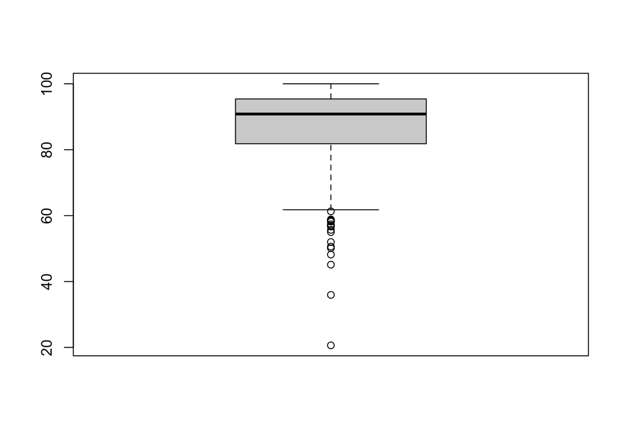

```r
# Checking outlier in successful intervention rate
boxplot(ratingdata$OverallInterventionsAchieved)
```

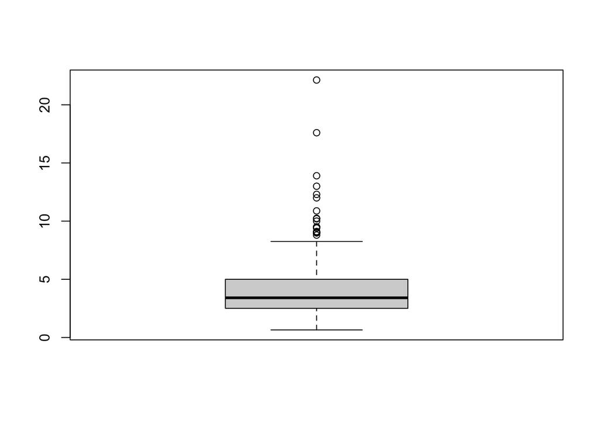

```r
# Checking outlier in successful intervention rate
boxplot(ratingdata$FTE)
```

Result: Data seems normal, the value are possible to be the real value (not input error). Conclusion: Keep all the data.

```r
# Create new data frame for further analysis & keep the original data
rtgdata <- ratingdata

# Change the "NR" and "NP" value to NA
rtgdata["ARatedInterventionsAchieved"][rtgdata["ARatedInterventionsAchieved"] == "NR"] <- NA
rtgdata["Total%ofBroadlyCompliantestablishments-A"][rtgdata["Total%ofBroadlyCompliantestablishments-A"] == "NP"] <- NA

# Convert from char to num data type
rtgdata$`Total%ofBroadlyCompliantestablishments-A` <- as.numeric(rtgdata$`Total%ofBroadlyCompliantestablishments-A`)
rtgdata$`ARatedInterventionsAchieved` <- as.numeric(rtgdata$`ARatedInterventionsAchieved`)

# create new column for analysis

# Number of rated establishment
rtgdata$ratedestablishment <- rtgdata$`Totalestablishments(includingnotyetrated&outside)`-rtgdata$Establishmentsnotyetratedforintervention - rtgdata$Establishmentsoutsidetheprogramme

rtgdata$FTEPerEstablishment <- 1000*rtgdata$FTE/rtgdata$ratedestablishment

rtgdata$ratedestablishmentin1000 <- rtgdata$ratedestablishment/1000

rtgdata$FTEAsProportion <- rtgdata$ratedestablishment*0.2
```

### 1a. Distribution of Percentage of Successful Enforcement Actions

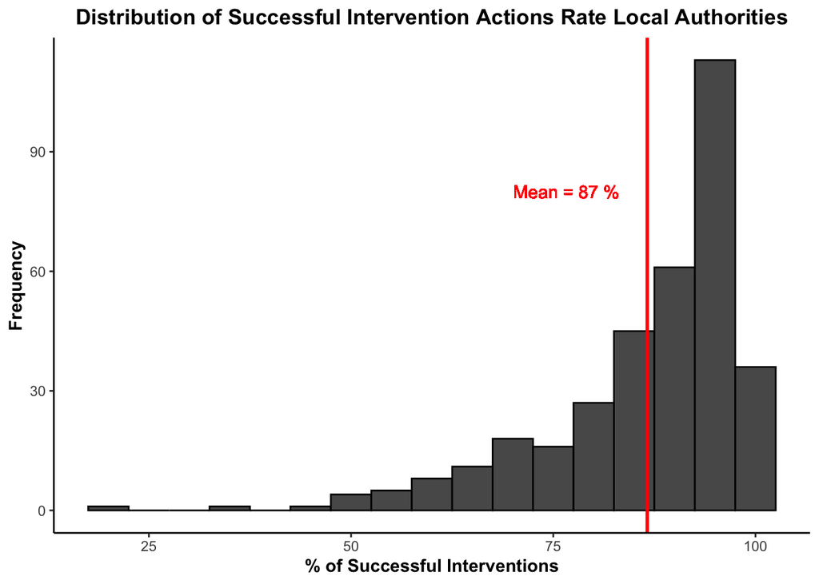

```r
# Density Plot
dist_plot <-
  ggplot(data = rtgdata)+
  geom_histogram(mapping = (aes(x=OverallInterventionsAchieved, y = ..density..)),binwidth = 5, color="black")+
  geom_density(aes(x=OverallInterventionsAchieved), fill = "red", alpha = 0.2)+
  geom_vline(aes(xintercept = mean(ratingdata$OverallInterventionsAchieved, na.rm = TRUE)), col = "red", size = 1)+
  geom_text(aes(x=mean(OverallInterventionsAchieved, na.rm = TRUE) - 10,
                label=paste("Mean =", as.character(round(mean(OverallInterventionsAchieved, na.rm=TRUE))),"%"),
                                           y=0.04), colour = "red")+
  ggtitle("Distribution of Successful Intervention Rate Accross Local Authorities")+
  labs(x = "% of Successful Interventions", y = "Density")+
  theme_classic()+
  theme(plot.title = element_text(hjust = 0.5))+
  theme(title = element_text(face="bold"))+
  theme(legend.position = "none")
# Frequency Plot
ggplot(data = rtgdata)+
  geom_histogram(mapping = (aes(x=OverallInterventionsAchieved)),binwidth = 5, color="black")+
  geom_vline(aes(xintercept = mean(ratingdata$OverallInterventionsAchieved, na.rm = TRUE)), col = "red", size = 1)+
  geom_text(aes(x=mean(OverallInterventionsAchieved, na.rm = TRUE) - 10,
                label=paste("Mean =", as.character(round(mean(OverallInterventionsAchieved, na.rm=TRUE))),"%"),
                                           y=80), colour = "red")+
  ggtitle("Distribution of Successful Intervention Actions Rate Local Authorities")+
  labs(x = "% of Successful Interventions", y = "Frequency")+
  theme_classic()+
  theme(plot.title = element_text(hjust = 0.5))+
  theme(title = element_text(face="bold"))+
  theme(legend.position = "none")
```

### 1b. Distribution of Percentage of Successful Enforcement Actions for Each Rating

```r
# Convert the dataset into long format

# Pick relevant columns
data_wide <- rtgdata[c("Country", "LAType", "LAName", "ARatedInterventionsAchieved","BRatedInterventionsAchieved","CRatedInterventionsAchieved","DRatedInterventionsAchieved","ERatedInterventionsAchieved", "FTE")]

data_wide$ARatedInterventionsAchieved <- as.numeric(data_wide$ARatedInterventionsAchieved)

# Convert the data from wide to long format
data_long <- data_wide %>%
  pivot_longer(
    cols = `ARatedInterventionsAchieved`:`ERatedInterventionsAchieved`,
    names_to = "rating",
    values_to = "interventionsuccessrate"
)

data_long$rating <- as.factor(data_long$rating)

str(data_wide)
```

```
## tibble [353 × 9] (S3: tbl_df/tbl/data.frame)
##  $ Country                    : Factor w/ 3 levels "England","Northern Ireland",..: 1 1 1 1 1 1 1 1 1 1 ...
##  $ LAType                     : Factor w/ 6 levels "District Council",..: 1 1 1 1 1 1 1 1 1 1 ...
##  $ LAName                     : chr [1:353] "Adur and Worthing" "Allerdale" "Amber Valley" "Arun" ...
##  $ ARatedInterventionsAchieved: num [1:353] 100 100 100 100 60 80 100 100 100 100 ...
##  $ BRatedInterventionsAchieved: num [1:353] 100 98.3 95.1 96.3 100 ...
##  $ CRatedInterventionsAchieved: num [1:353] 95.5 89.7 97 94.4 78.8 ...
##  $ DRatedInterventionsAchieved: num [1:353] 96 93 91.8 92.6 85.3 ...
##  $ ERatedInterventionsAchieved: num [1:353] 94 85.1 72.3 95.5 68.3 ...
##  $ FTE                        : num [1:353] 5 4 3.5 4 2 4.65 2.5 5 2 4.2 ...
```

```r
# Create a summary of Response Time data
mean_achieved <- data_long %>%
  group_by(rating) %>%
  summarise(successrate = mean(interventionsuccessrate, na.rm = TRUE))

# Create a new column to save the label for the vline
mean_achieved$'SuccessRateLabel' <- paste("Mean = ", as.character(round(mean_achieved$successrate)),"%")

# Create label for the plot
rating.labs <- c("ARatedInterventionsAchieved" = "Rating A" , "BRatedInterventionsAchieved" = "Rating B", "CRatedInterventionsAchieved" = "Rating C",
                 "DRatedInterventionsAchieved" = "Rating D", "ERatedInterventionsAchieved" = "Rating E")
```

```r
# Frequency Plot
rating_freqplot<-
  ggplot(data = data_long)+
  geom_histogram(mapping = (aes(x=interventionsuccessrate, fill = rating)), color="black")+
  geom_vline(data = mean_achieved,aes(xintercept = successrate), col = "red", size = 1)+
  geom_text(data = mean_achieved,aes(x=25, label=SuccessRateLabel,
                                          y=c(150, 80, 80, 70, 40)),colour="black")+
  #ggtitle("Distribution of Successful Enforcement Actions for Each Rating")+
  labs(x = "% of Successful Interventions", y = "Frequency")+
  facet_grid(rating ~., labeller = labeller(rating = rating.labs), scales = "free")+
  theme_classic()+
  theme(plot.title = element_text(hjust = 0.5))+
  theme(title = element_text(face="bold"))+
  theme(legend.position = "none")

# Density Plot
rating_densplot <-
  ggplot(data = data_long)+
  geom_histogram(mapping = (aes(x=interventionsuccessrate, y= ..density.., fill = rating)), color="black")+
  geom_density(aes(x=interventionsuccessrate), fill = "black", alpha = 0.3)+
  geom_vline(data = mean_achieved,aes(xintercept = successrate), col = "red", size = 1)+
  geom_text(data = mean_achieved,aes(x=25, label=SuccessRateLabel,
                                          y=c(0.15, 0.1, 0.075, 0.06, 0.03)),colour="black")+
  #ggtitle("Distribution of Successful Enforcement Actions for Each Rating")+
  labs(x = "% of Successful Interventions", y = "Density")+
  facet_grid(rating ~., labeller = labeller(rating = rating.labs), scales = "free")+
  theme_classic()+
  theme(plot.title = element_text(hjust = 0.5))+
  theme(title = element_text(face="bold"))+
  theme(legend.position = "none")
```

### 2. Examine whether there is a relationship between proportion of successful responses and the number of FTE food safety employees in each local authority.

```r
# Shapiro Test to Test Normality of The Data
shapiro.test(rtgdata$OverallInterventionsAchieved)
```

```
##
##  Shapiro-Wilk normality test
##
## data:  rtgdata$OverallInterventionsAchieved
## W = 0.84365, p-value < 2.2e-16
```

```r
shapiro.test(rtgdata$FTE)
```

```
##
##  Shapiro-Wilk normality test
##
## data:  rtgdata$FTE
## W = 0.80175, p-value < 2.2e-16
```

From the output, the p-value < 0.05 implying that the distribution of the data are significantly different from normal distribution. In other words, we can not assume the normality.

Therefore, in checking correlation, it is more suitable to use ‘spearman’ method instead of pearson.

```r
# Checking the correlation between FTE of FSA and Percentage of Intervention Achieved
rcorr(as.matrix(select(rtgdata, OverallInterventionsAchieved, FTE, ratedestablishment)), type = "spearman")
```

```
##                              OverallInterventionsAchieved  FTE ratedestablishment
## OverallInterventionsAchieved                         1.00 0.00              -0.16
## FTE                                                  0.00 1.00               0.79
## ratedestablishment                                  -0.16 0.79               1.00
##
## n= 347
##
##
## P
##                              OverallInterventionsAchieved FTE    ratedestablishment
## OverallInterventionsAchieved                              0.9771 0.0034
## FTE                          0.9771                              0.0000
## ratedestablishment           0.0034                       0.0000
```

The correlation between FTE and Overall Intervention Achieved is not significant under NHST (p-value = 0.9771, n = 347).

We can see the relationship between FTE and Overall Intervention Achieved visually with the graph below:

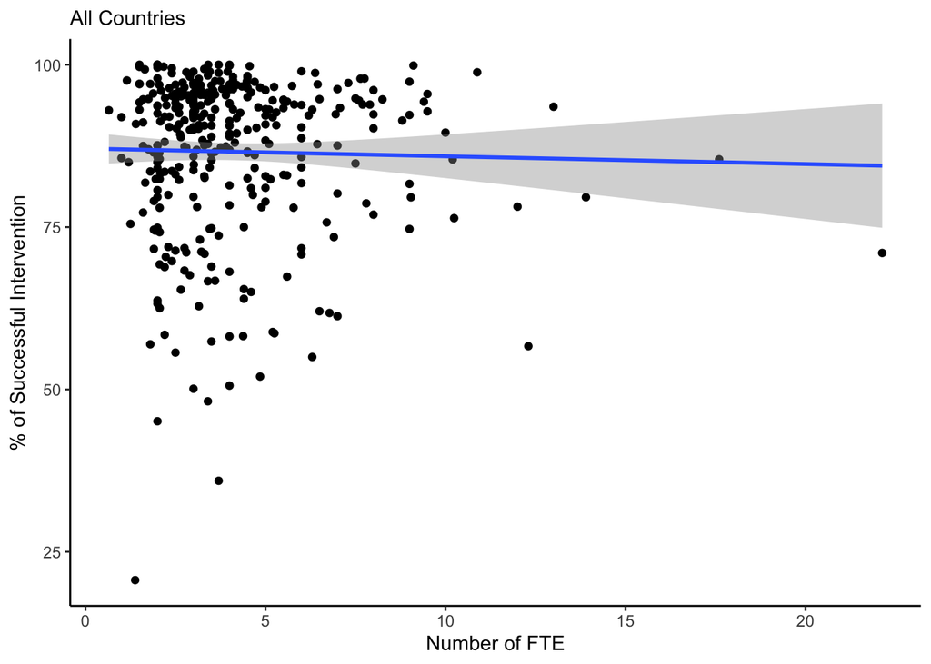

```r
# FTE vs Overall Intervention Achieved
( allcountry <-
  ggplot(rtgdata, aes(y=OverallInterventionsAchieved, x=FTE)) +
  geom_point() +
  labs(x="Number of FTE", y="% of Successful Intervention", subtitle = "All Countries") +
  scale_y_continuous(breaks = c(0, 25, 50, 75, 100))+
  geom_smooth(method=lm)+
  theme_classic()+
  theme(plot.title = element_text(hjust = 0)))
```

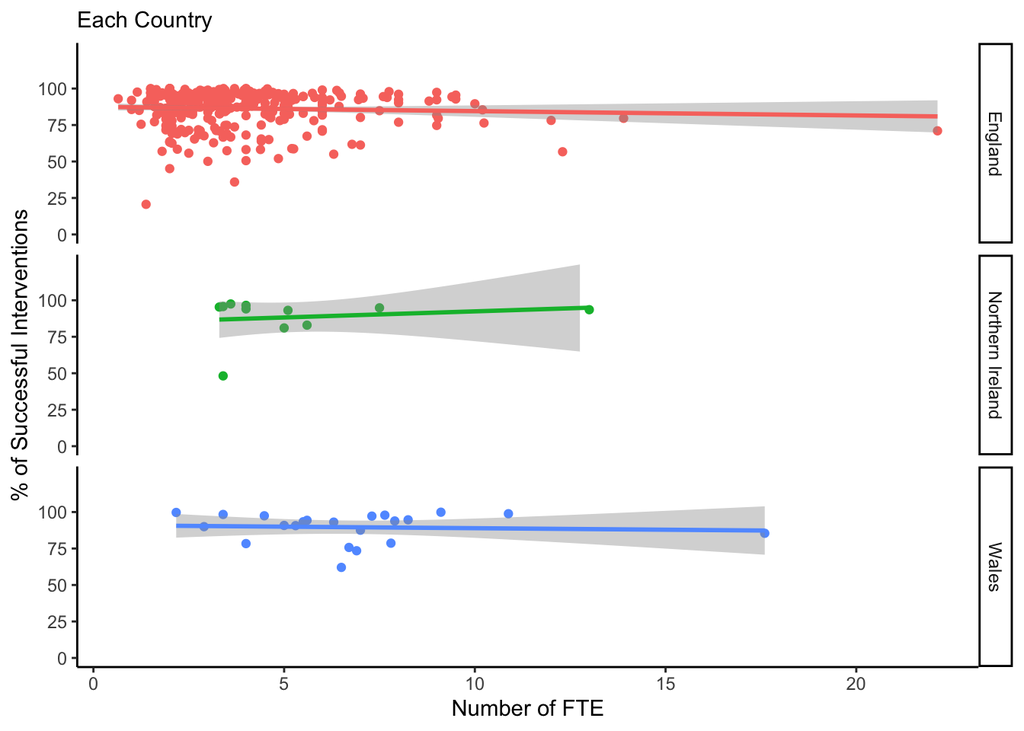

```r
# FTE vs Overall Intervention Achieved in Each Country
( eachcountry <-
  ggplot(rtgdata, aes(y=OverallInterventionsAchieved, x=FTE, colour = Country)) +
  geom_point() +
  scale_y_continuous(limits =c(0,125), breaks =c(0,25,50,75,100))+
  facet_grid(Country ~.)+
  geom_smooth(method=lm)+
  labs(x = "Number of FTE", y = "% of Successful Interventions", subtitle = "Each Country")+
  theme_classic()+
  theme(plot.title = element_text(hjust = 0))+
  theme(legend.position="none")
)
```

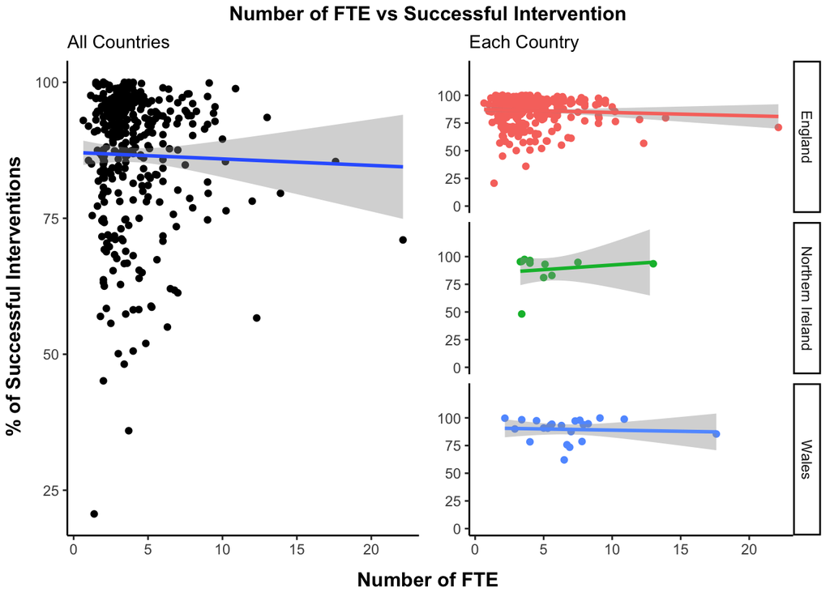

```r
# Remove axis titles from all plots
p = list(allcountry,eachcountry) %>% map(~.x + labs(x=NULL, y=NULL))

# Arrange the plot
grid.arrange(grobs=p, ncol = 2, top = text_grob("Number of FTE vs Successful Intervention", size = 12, face = "bold"), left = text_grob("% of Successful Interventions", rot = 90, face ="bold"), bottom = text_grob("Number of FTE", face = "bold"))
```

We can then try to build simple linear model to predict the Overall Intervention Achieved by the FTE.

```r
# Create a linear model to predict success rate based on the number of FTE
successrate_by_FTE <- lm(OverallInterventionsAchieved ~ FTE, data = rtgdata)
summary(successrate_by_FTE)
```

```
##
## Call:
## lm(formula = OverallInterventionsAchieved ~ FTE, data = rtgdata)
##
## Residuals:
##     Min      1Q  Median      3Q     Max
## -66.304  -4.575   4.067   8.658  13.860
##
## Coefficients:
##             Estimate Std. Error t value Pr(>|t|)
## (Intercept)  87.1091     1.2828  67.905   <2e-16 ***
## FTE          -0.1195     0.2675  -0.447    0.655
## ---
## Signif. codes:  0 '***' 0.001 '**' 0.01 '*' 0.05 '.' 0.1 ' ' 1
##
## Residual standard error: 12.4 on 345 degrees of freedom
##   (6 observations deleted due to missingness)
## Multiple R-squared:  0.0005787,  Adjusted R-squared:  -0.002318
## F-statistic: 0.1998 on 1 and 345 DF,  p-value: 0.6552
```

```r
cbind(coefficient=coef(successrate_by_FTE), confint(successrate_by_FTE))
```

```
##             coefficient      2.5 %     97.5 %
## (Intercept)  87.1091495 84.5860343 89.6322647
## FTE          -0.1195469 -0.6456029  0.4065092
```

The model ‘successrate_by_FTE’ is a linear regression of the Overall Intervention Achieved (%) by the number of Full Time Employee (FTE). The tells us that there is a 0.12% decrease of Overall Intervention Achieved for every increase of 1 FTE 95% CI [-0.64 - 0.4]. However, the result also shows that the FTE is not a significant predictor for Overall Intervention Achieved (t(345) = -0.447, p = 0.655, 95% CI [-0.64 - 0.4]).

```r
# Create variable to store data for each country
englanddata <- rtgdata %>%
  filter (Country == "England")

northernirelanddata <- rtgdata %>%
  filter (Country == "Northern Ireland")

walesdata <- rtgdata %>%
  filter (Country == "Wales")
```

```r
# Create a linear model to predict success rate based on the number of FTE for each country

# England
successrate_by_FTE_England <- lm(OverallInterventionsAchieved ~ FTE, data = englanddata)
summary(successrate_by_FTE_England)
```

```
##
## Call:
## lm(formula = OverallInterventionsAchieved ~ FTE, data = englanddata)
##
## Residuals:
##     Min      1Q  Median      3Q     Max
## -66.448  -4.508   4.141   8.851  13.691
##
## Coefficients:
##             Estimate Std. Error t value Pr(>|t|)
## (Intercept)  87.4989     1.3754  63.617   <2e-16 ***
## FTE          -0.2975     0.3051  -0.975     0.33
## ---
## Signif. codes:  0 '***' 0.001 '**' 0.01 '*' 0.05 '.' 0.1 ' ' 1
##
## Residual standard error: 12.46 on 312 degrees of freedom
##   (6 observations deleted due to missingness)
## Multiple R-squared:  0.00304,    Adjusted R-squared:  -0.0001555
## F-statistic: 0.9513 on 1 and 312 DF,  p-value: 0.3301
```

```r
cbind(coefficient=coef(successrate_by_FTE_England), confint(successrate_by_FTE_England))
```

```
##             coefficient      2.5 %     97.5 %
## (Intercept)  87.4989213 84.7926706 90.2051721
## FTE          -0.2975436 -0.8977805  0.3026933
```

```r
# Northern Ireland
successrate_by_FTE_NorthernIreland <- lm(OverallInterventionsAchieved ~ FTE, data = northernirelanddata)
summary(successrate_by_FTE_NorthernIreland)
```

```
##
## Call:
## lm(formula = OverallInterventionsAchieved ~ FTE, data = northernirelanddata)
##
## Residuals:
##     Min      1Q  Median      3Q     Max
## -38.698  -3.566   4.798   8.699  10.435
##
## Coefficients:
##             Estimate Std. Error t value Pr(>|t|)
## (Intercept)  84.0288     9.8090   8.566 1.28e-05 ***
## FTE           0.8379     1.6546   0.506    0.625
## ---
## Signif. codes:  0 '***' 0.001 '**' 0.01 '*' 0.05 '.' 0.1 ' ' 1
##
## Residual standard error: 14.97 on 9 degrees of freedom
## Multiple R-squared:  0.0277, Adjusted R-squared:  -0.08033
## F-statistic: 0.2564 on 1 and 9 DF,  p-value: 0.6248
```

```r
cbind(coefficient=coef(successrate_by_FTE_NorthernIreland), confint(successrate_by_FTE_NorthernIreland))
```

```
##             coefficient     2.5 %     97.5 %
## (Intercept)  84.0288130 61.839237 106.218389
## FTE           0.8378766 -2.905125   4.580878
```

```r
# Wales
successrate_by_FTE_Wales <- lm(OverallInterventionsAchieved ~ FTE, data = walesdata)
summary(successrate_by_FTE_Wales)
```

```
##
## Call:
## lm(formula = OverallInterventionsAchieved ~ FTE, data = walesdata)
##
## Residuals:
##     Min      1Q  Median      3Q     Max
## -27.605  -1.966   3.430   7.623  10.771
##
## Coefficients:
##             Estimate Std. Error t value Pr(>|t|)
## (Intercept)  91.0151     5.2247  17.420 1.48e-13 ***
## FTE          -0.2093     0.7036  -0.297    0.769
## ---
## Signif. codes:  0 '***' 0.001 '**' 0.01 '*' 0.05 '.' 0.1 ' ' 1
##
## Residual standard error: 10.3 on 20 degrees of freedom
## Multiple R-squared:  0.004404,   Adjusted R-squared:  -0.04538
## F-statistic: 0.08847 on 1 and 20 DF,  p-value: 0.7692
```

```r
cbind(coefficient=coef(successrate_by_FTE_Wales), confint(successrate_by_FTE_Wales))
```

```
##             coefficient     2.5 %     97.5 %
## (Intercept)  91.0151486 80.116665 101.913632
## FTE          -0.2092914 -1.677032   1.258449
```

The models of each country show that FTE is not a significant predictor for successful intervention rate. For England, the model shows that there is a $0.29$% decrease of successful intervention rate for every additional of 1 FTE ($t(312) = -0.975$, $p = 0.33$, 95% CI [$-0.89 - 0.3$]). In Northern Ireland, there is a $0.83$% increase of successful intervention rate for every increase of 1 FTE ($t(9) = 0.506$, $p = 0.625$, 95% CI [$-2.9 - 4.5$]). Finally, for Wales the model shows that there is a $0.2$% decrease of successful intervention rate for 1 additional FTE (($t(20) = -0.297$, $p = 0.769$, 95% CI [$-1.67 - 1.2$])).

### 3. Examine whether there is a relationship between proportion of successful responses and the number of employees as a proportion of the number of establishments in the local authority.

```r
# Shapiro-Wilk Test to test normality
shapiro.test(rtgdata$FTEPerEstablishment)
```

```
##
##  Shapiro-Wilk normality test
##
## data:  rtgdata$FTEPerEstablishment
## W = 0.89675, p-value = 1.353e-14
```

From the output, the p-value < 0.05 implying that the distribution of the data are significantly different from normal distribution. In other words, we can not assume the normality.

Therefore, in checking correlation, it is more suitable to use ‘spearman’ method instead of pearson.

```r
# Checking the correlation between FTE of FSA and Percentage of Intervention Achieved
rcorr(as.matrix(select(rtgdata, OverallInterventionsAchieved, FTEPerEstablishment)), type = "spearman")
```

```
##                              OverallInterventionsAchieved FTEPerEstablishment
## OverallInterventionsAchieved                         1.00                0.24
## FTEPerEstablishment                                  0.24                1.00
##
## n= 347
##
##
## P
##                              OverallInterventionsAchieved FTEPerEstablishment
## OverallInterventionsAchieved                               0
## FTEPerEstablishment           0
```

The correlation between the FTE per Total Rated Establishment and Overall Intervention Achieved is significant under NHST (p-value < 0.001, n = 347). This tells us that the r-value is not zero, but we can see that it is still small: r = 0.24 (5.8% shared variance).

We can see the relationship between FTE per Total Rated Establishment and Overall Intervention Achieved visually with the graph below:

```r
# Create a plot showing relationship between number of FTE per Total Rated Establishments and Overall Intervention Achieved
FTE_Per_Est_Plot <-
  ggplot(rtgdata, aes(x = FTEPerEstablishment, y = OverallInterventionsAchieved)) +
  geom_point() +
   labs(x="FTE per Rated Establishment", y="% of Successful Intervention",
       subtitle="Each point is a Local Authority \nThe shaded area shows the 95% CI for the best-fitting regression line") +
  scale_y_continuous(limits =c(0,125), breaks = c(0, 25, 50, 75, 100))+
  geom_smooth(method=lm)+
  ggtitle("FTE Per Total Rated Establishment vs. Succesful Intervention")+
  labs(x = "FTE per Total Rated Establishment (x1,000)", y = "% of Successful Interventions")+
  theme_classic()+
  theme(plot.title = element_text(hjust = 0))+
  theme(title = element_text(face="bold"))
```

We can then try to build simple linear model to predict the Overall Intervention Achieved by the FTE per Total Rated Establishment.

```r
# Create a linear model to predict success rate based on the number of FTE
successrate_by_FTE_per_RatedEstablishment <- lm(OverallInterventionsAchieved ~ FTEPerEstablishment, data = rtgdata)
summary(successrate_by_FTE_per_RatedEstablishment)
```

```
##
## Call:
## lm(formula = OverallInterventionsAchieved ~ FTEPerEstablishment,
##     data = rtgdata)
##
## Residuals:
##     Min      1Q  Median      3Q     Max
## -61.181  -5.341   4.326   8.321  15.998
##
## Coefficients:
##                     Estimate Std. Error t value Pr(>|t|)
## (Intercept)          79.5356     1.9289  41.233  < 2e-16 ***
## FTEPerEstablishment   2.4074     0.6171   3.901 0.000115 ***
## ---
## Signif. codes:  0 '***' 0.001 '**' 0.01 '*' 0.05 '.' 0.1 ' ' 1
##
## Residual standard error: 12.14 on 345 degrees of freedom
##   (6 observations deleted due to missingness)
## Multiple R-squared:  0.04225,    Adjusted R-squared:  0.03948
## F-statistic: 15.22 on 1 and 345 DF,  p-value: 0.000115
```

```r
cbind(coefficient=coef(successrate_by_FTE_per_RatedEstablishment), confint(successrate_by_FTE_per_RatedEstablishment))
```

```
##                     coefficient    2.5 %    97.5 %
## (Intercept)           79.535642 75.74169 83.329596
## FTEPerEstablishment    2.407398  1.19372  3.621076
```

### Examine whether employing more professional enforcement officers increases the likelihood of establishments successfully responding to enforcement actions

To answer the question whether employing more professional enforcement officers increases the likelihood of establishments successfully responding to enforcement actions, it is interesting to also investigate the effect of both Number of FTE and Number of Rated Establishment within the Local Authorities. As demonstrated in the previous question, combining the value of FTE and Number of Rated Establishment as a proportion leads to significant predictor.

```r
# Create a linear model with FTE and Total Number of Rated Establishment as Predictors
successrate_by_FTE_and_RatedEstablishment <- lm(OverallInterventionsAchieved ~ FTE + ratedestablishmentin1000, data = rtgdata)
summary(successrate_by_FTE_and_RatedEstablishment)
```

```
##
## Call:
## lm(formula = OverallInterventionsAchieved ~ FTE + ratedestablishmentin1000,
##     data = rtgdata)
##
## Residuals:
##     Min      1Q  Median      3Q     Max
## -62.360  -5.243   4.397   8.290  20.376
##
## Coefficients:
##                          Estimate Std. Error t value Pr(>|t|)
## (Intercept)               88.2609     1.2820  68.847  < 2e-16 ***
## FTE                        1.3800     0.4408   3.130   0.0019 **
## ratedestablishmentin1000  -4.9282     1.1672  -4.222  3.1e-05 ***
## ---
## Signif. codes:  0 '***' 0.001 '**' 0.01 '*' 0.05 '.' 0.1 ' ' 1
##
## Residual standard error: 12.11 on 344 degrees of freedom
##   (6 observations deleted due to missingness)
## Multiple R-squared:  0.04982,    Adjusted R-squared:  0.04429
## F-statistic: 9.018 on 2 and 344 DF,  p-value: 0.0001524
```

```r
cbind(coefficient=coef(successrate_by_FTE_and_RatedEstablishment), confint(successrate_by_FTE_and_RatedEstablishment))
```

```
##                          coefficient      2.5 %    97.5 %
## (Intercept)                88.260889 85.7393658 90.782411
## FTE                         1.379971  0.5128711  2.247070
## ratedestablishmentin1000   -4.928159 -7.2239832 -2.632335
```

As expected, both of FTE and Number of Rated Establishment are significant prediction for Overall Intervention Achieved.

In the model involving both predictors, the successful intervention rate increase by a statistically significant $1.38$%, $t(344) = 3.13, p=0.0019$, for every additional of 1 FTE, holding the number of establishment constant.

On the contrary, the successful intervention rate decreases by a statistically significant $4.93$%, $t(344)= -4.22, p<.0001$, for every additional of 1,000 establishments, holding the number of FTE constant.

```r
anova(successrate_by_FTE, successrate_by_FTE_and_RatedEstablishment)
```

```
## Analysis of Variance Table
##
## Model 1: OverallInterventionsAchieved ~ FTE
## Model 2: OverallInterventionsAchieved ~ FTE + ratedestablishmentin1000
##   Res.Df   RSS Df Sum of Sq      F    Pr(>F)
## 1    345 53021
## 2    344 50408  1    2612.1 17.826 3.102e-05 ***
## ---
## Signif. codes:  0 '***' 0.001 '**' 0.01 '*' 0.05 '.' 0.1 ' ' 1
```

With anova test, it is concluded that adding number of rated establishments as independent variable significantly improves the overall model fit compared to the base model, in which only FTE is considered as the independent variable $F(1,344)= 17.83, p < .0001$.

```r
vif(successrate_by_FTE_and_RatedEstablishment)
```

```
##                      FTE ratedestablishmentin1000
##                 2.849347                 2.849347
```

Both VIF value are below 5. It is justified to keep both variable in the model.

```r
# Create a dataframe as the input to the model
predict_data <- expand.grid(FTE = seq(1, 20, 0.5),
                            ratedestablishmentin1000 =seq(3,10,0.5))

# Predict the intervention success rate using FTE and Number of Rated Establishment
predict_data <- mutate(predict_data,
                         OverallInterventionsAchieved = predict(successrate_by_FTE_and_RatedEstablishment, predict_data))

# Create dataframe for example
example_data <- expand.grid(FTE = c(7, 13),
                            ratedestablishmentin1000 = c(5,8))

example_data <- example_data[-c(4), ]

example_data$State <- c("Initial", "Scenario 1", "Scenario 2")

example_data[nrow(example_data) +1,] = c(20, 3, "Optimal")

example_data$FTE <- as.numeric(example_data$FTE)

example_data$ratedestablishmentin1000 <- as.numeric(example_data$ratedestablishmentin1000)
```

```r
# Create a plot showing the relationship between number of FTE and number of rated establishment as predictors for successful intervention  rate
cont_plot <-
ggplot()+
scale_color_viridis_c(option = "viridis")+
geom_point(data = predict_data, aes(x=FTE, y = ratedestablishmentin1000, color = OverallInterventionsAchieved), size = 15, shape = 15)+
ggtitle("FTE and Number of Rated Establishment vs Successful Intervention Rate")+
labs(x = "FTE", y = "Total Number of Rated Establishment (x1,000)", color = "% Successful Intervention")+
scale_x_continuous(limits = c(1,20), breaks = seq(2,20,2))+
scale_y_continuous(limits = c(3,10), breaks = seq(3,10,1))+
theme_classic()+
theme(plot.title = element_text(hjust = 0.5))+
theme(title = element_text(face="bold", size = 8))+
geom_point(data = example_data, aes(FTE, ratedestablishmentin1000, shape = State), size = 3)
```

## Section 2

### Introduction

This report elaborate data from The Food Standards Agency (FSA), which is responsible for monitoring and reporting on the performance of local authority (LA) food law enforcement services in England, Wales and Northern Ireland. Data are collected annually from all Local Authorities (LAs), on food law enforcement activity within food establishments.

This report covers the period 1 April 2019 to 31 March 2020 so provides a picture of local authority activity at the point the UK-wide lockdown to control the spread of COVID-19 began in late March 2020.

Particularly, this report will focus on whether establishments successfully respond to intervention actions and whether employing more professional enforcement officers increases the likelihood of establishments successfully responding to enforcement actions.

### 1. Distribution of Rate of Successful Interventions Accross Local Authorities

The distribution of Rate of Successful Intervention across local authorities is shown in the figure 1 below:

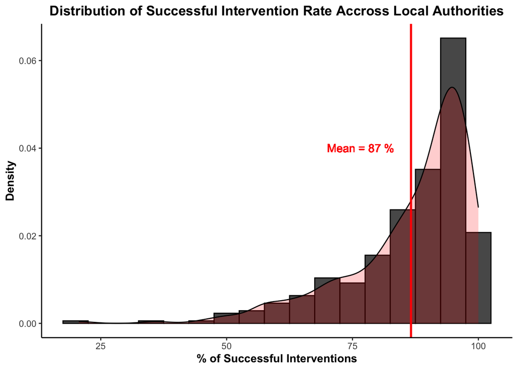

**Figure 1. Distribution of Rate of Successful Intervention for All Establishment**

To understand better about the distribution of successful intervention rate, a closer look on how the successful intervention rate differs for each establishment rating is provided. Figure 2 below shows the successful intervention rate for each ratings:

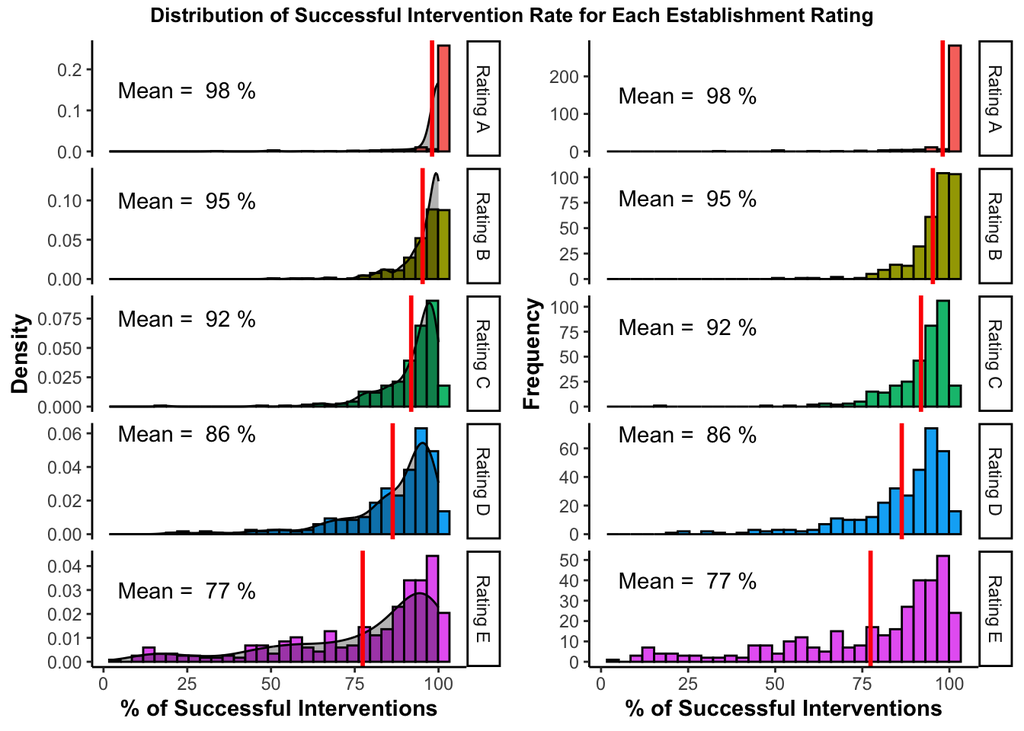

**Figure 2. Distribution of Rate of Successful Intervention for Each Establishment Rating**

Establishments within each local authority are rated for their potential impact on public health (essentially a measure of how many people could they cause sickness to, and how seriously, if they serve bad food). These ratings are letter grades from A – meaning the greatest potential impact – to E – the lowest potential impact upon public health.

Figure 2 shows that A-rated establishments has the highest successful intervention rate ($98$%). The distribution of successful intervention rate from A-rated establishments show that most of those establishments have $100$% success rate. Besides A-rated establishment, only B-rated and C-rated establishment have greater successful intervention rate than the overall establishment with $95$% and $92$% successful intervention rate respectively. D-rated establishments get a slightly below overall successful intervention rate with $86$% and E-rated establishments only get 77% successful intervention rate, or 10% below the overall rate.

There is a noticeable trend that the establishments with high potential impact on public health will have greater successful intervention rate compared to the establishments with low impact. The trend is expected since establishments with high impact on public health must be ensured to have successful intervention rate as high as possible. To improve overall successful intervention rate, local authorities can improve the rate for E-rated establishments while keeping the successful intervention for high impact establishments high.

### 2. Relationship Between Successful Intervention Rate and The Number of Full Time Equivalent (FTE) of Food Standard Agency (FSA) Employees in Each Local Authority

In an effort to improve the successful intervention rate, Figure 3 below is prepared to examine the relationship between proportion of successful responses and the number of Full Time Equivalent (FTE) of Food Standard Agency (FSA) employees in each local authority.

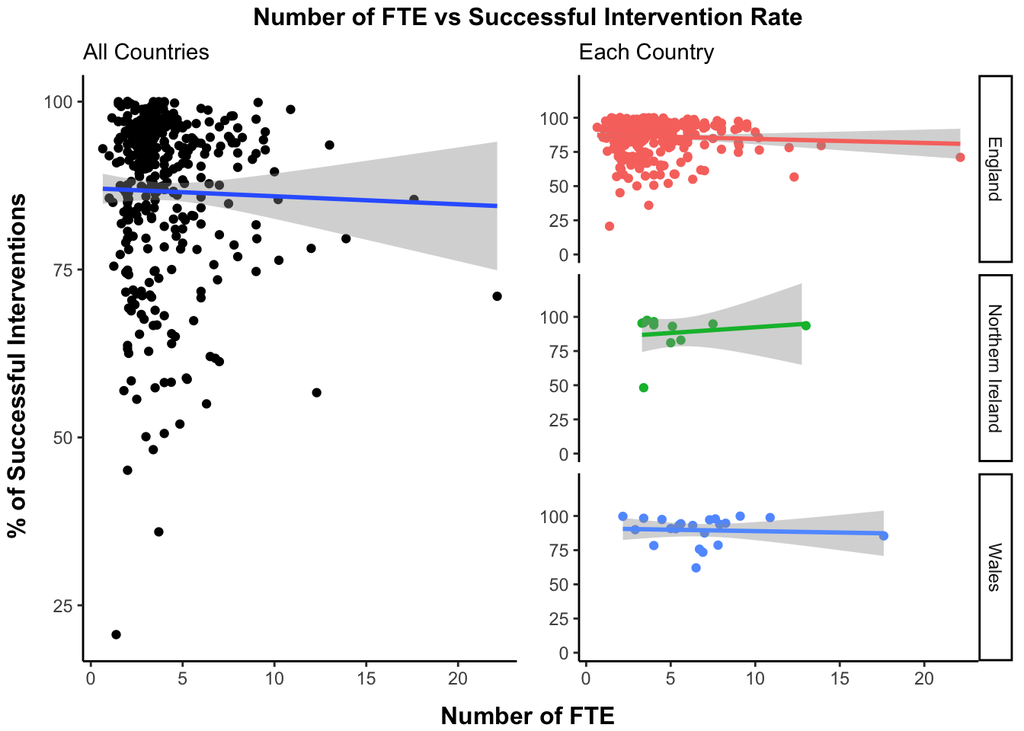

**Figure 3. Number of FTE vs Successful Intervention Rate**

To get a more complete understanding of the relationship between the two variables, a linear model is built. For overall data, the model shows that there is a $0.12$% decrease of successful intervention rate for every increase of 1 FTE $95$% CI [$-0.64 - 0.4$]. However, the result also shows that the FTE is not a significant predictor for successful intervention rate ($t(345) = -0.447$, $p = 0.655$, 95% CI [$-0.64 - 0.4$]).

The relationship between the two variables is also examined for each country. For England, the model shows that there is a $0.29$% decrease of successful intervention rate for every additional of 1 FTE ($t(312) = -0.975$, $p = 0.33$, 95% CI [$-0.89 - 0.3$]). In Northern Ireland, there is a $0.83$% increase of successful intervention rate for every increase of 1 FTE ($t(9) = 0.506$, $p = 0.625$, 95% CI [$-2.9 - 4.5$]). Finally, for Wales the model shows that there is a $0.2$% decrease of successful intervention rate for 1 additional FTE (($t(20) = -0.297$, $p = 0.769$, 95% CI [$-1.67 - 1.2$])). However, similar with the overall result, the result from each country shows that there is **no significant** relationship between number of FTE and the successful intervention rate in each country.

**Conclusion:** Number of FTE is not a significant predictor for successful intervention rate.

### 3. Relationship Between Successful Intervention Rate and The Number of Full Time Equivalent (FTE) of Food Standard Agency (FSA) Employees as a Proportion of Total Number of Rated Establishments in Each Local Authority

After concluding that number of FTE is not a significant predictor for successful intervention rate, another variable is studied. A linear model is built to predict successful intervention rate by number of FTE as a proportion of total number of rated establishments.

Figure 4 below depicts the relationship between successful intervention rate and FTE as a proportion of total number of rated establishments.

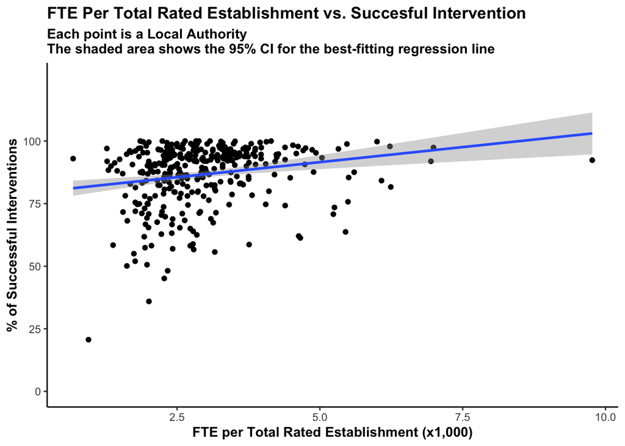

**Figure 4. Number of FTE per Total Number of Rated Establishment vs Successful Intervention Rate**

As suggested from the model, with the increase of the proportion of FTE per total rated establishment, the successful intervention rate also increases.

**Conclusion:** Number of FTE alone is not a significant predictor for successful intervention rate. However, number of FTE as a proportion of total number of rated establishment is a significant predictor for successful intervention rate

### Does Employing More Professional Enforcement Officers Increases The Likelihood of Establishments Successfully Responding to Intervention Actions?

The answer is : depend on the total number of rated establishment in the respective local authority, as suggested in the previous section. Another way to interpret section 3 is to build another model to predict successful intervention rate by FTE **AND** number of rated establishments as the predictors. As expected, both variable become significant predictors for successful intervention rate.

In the model involving both predictors, the successful intervention rate increase by a statistically significant $1.38$%, $t(344) = 3.13, p=0.0019$, for every additional of 1 FTE, holding the number of establishment constant.

On the contrary, the successful intervention rate decreases by a statistically significant $4.93$%, $t(344)= -4.22, p<.0001$, for every additional of 1,000 establishments, holding the number of FTE constant.

With anova test, it is concluded that adding number of rated establishments as independent variable significantly improves the overall model fit compared to the base model, in which only FTE is considered as the independent variable $F(1,344)= 17.83, p < .0001$.

Figure 5 illustrates the relationship between two independent variable and the target variable.

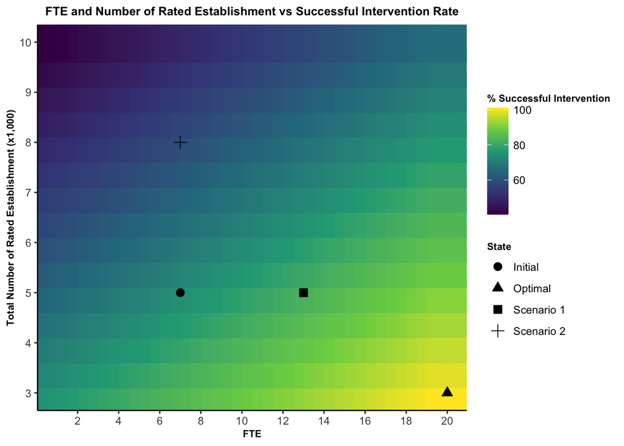

**Figure 5. Number of FTE and Total Number of Rated Establishment vs Successful Intervention Rate**

The top left corner of the graph in Figure 5 shows the condition where a local authority has low FTE and high number of establishments and as the model predict, the successful intervention rate is poor. On the opposite, in the bottom right corner shows the condition where a local authority has high FTE and low number of establishments and thus, the successful intervention rate is very high.

Employing more officers (or increasing the number of FTE) will improve the successful intervention rate, assuming the number of establishments stays constant. This scenario is represented in Figure 5 by moving from the circle to the rectangle. Similarly, growing number of establishment in a local authority will lead to a decrease in successful intervention rate if the number of FTE stays the same (moving from the circle to the plus sign).

To achieve high successful intervention rate (represented by triangle), a local authority must have a proportion of approximately 20 FTE for every 3,000 establishments.

**Conclusion:** Employing more Food Safety Agency employees in a local authority will improve the successful intervention rate, assuming the number of establishment within the respective local authority does not change. A local authority can achieve high successful intervention rate by having a proportion of $1$ FTE for every $150$ establishments.

# Question 2

# The Scenario

The management team of a publishing company want to better understand factors that affect daily sales of books.

The data provided contains information on e-book sales over a period of many months. Each row in the data represents one book. The values of the variables are taken across the entire time period.

So daily.sales is the average number of sales (minus refunds) across all days in the period, and sale.price is the average price for which the book sold across all sales in the period.

Description of each variable in the dataset are shown below.

| Variable | Description |
| --- | --- |
| sold.by | Name of the publisher |
| publisher.type | Classification of the publisher |
| genre | Genre of the book |
| avg.review | Average score of the book review |
| daily.sales | The average number of sales (minus refunds) across all days in the period |
| total.reviews | Total number of review for the book |
| sales.price | The average price for which the book sold across all sales in the period (assumption: in GBP) |

# The Request

The management team would like you to provide a report that addresses the following:

1. Do books from different genres have different daily sales on average?
2. Do books have more/fewer sales depending upon their average review scores and total number of reviews.
3. What is the effect of sale price upon the number of sales, and is this different across genres?

# The Answer

The answer have two sections.

The first section includes the code to perform all stages of the data analysis. This section could be shared with someone else who is not familiar with the data or project, but is an expert in R and statistics.

The second section is a polished and professional report presenting and interpreting the findings for the panel of management board of the publishing company.

## Section 1

### Data Preparation

```r
# Read the dataset
salesdata <- read.csv("publisher_sales.csv")
```

```r
# Check the summary and the structure of the data
summary(salesdata)
```

```
##    sold.by          publisher.type        genre             avg.review     daily.sales
##  Length:6000        Length:6000        Length:6000        Min.   :0.000   Min.   : -0.53
##  Class :character   Class :character   Class :character   1st Qu.:4.100   1st Qu.: 56.77
##  Mode  :character   Mode  :character   Mode  :character   Median :4.400   Median : 74.29
##                                                           Mean   :4.267   Mean   : 79.11
##                                                           3rd Qu.:4.620   3rd Qu.: 98.02
##                                                           Max.   :4.980   Max.   :207.98
##  total.reviews     sale.price
##  Min.   :  0.0   Min.   : 0.740
##  1st Qu.:105.0   1st Qu.: 7.140
##  Median :128.0   Median : 8.630
##  Mean   :132.6   Mean   : 8.641
##  3rd Qu.:163.0   3rd Qu.:10.160
##  Max.   :248.0   Max.   :17.460
```

```r
str(salesdata)
```

```
## 'data.frame':    6000 obs. of  7 variables:
##  $ sold.by       : chr  "Random House LLC" "Amazon Digital Services,  Inc." "Amazon Digital Services,  Inc." "Amazon Digital Services,  Inc." ...
##  $ publisher.type: chr  "big five" "indie" "small/medium" "small/medium" ...
##  $ genre         : chr  "childrens" "non_fiction" "non_fiction" "fiction" ...
##  $ avg.review    : num  4.44 4.19 3.71 4.72 4.65 4.81 4.33 4.21 3.95 4.66 ...
##  $ daily.sales   : num  61.5 74.9 66 85.2 37.7 ...
##  $ total.reviews : int  92 130 118 179 111 106 205 86 161 81 ...
##  $ sale.price    : num  8.03 9.08 9.48 12.32 5.78 ...
```

```r
# Change data types for Country and LAtype columns
# First generate a vector to keep the column names
columns <- c("sold.by", "publisher.type", "genre")

# Then, set the correct data types for the defined columns
salesdata[columns] <- lapply(salesdata[columns], factor)

# To check the new structure of the data after several changes above
str(salesdata)
```

```
## 'data.frame':    6000 obs. of  7 variables:
##  $ sold.by       : Factor w/ 13 levels "Amazon Digital Services,  Inc.",..: 11 1 1 1 13 13 1 6 1 1 ...
##  $ publisher.type: Factor w/ 5 levels "amazon","big five",..: 2 3 5 5 2 2 5 2 5 5 ...
##  $ genre         : Factor w/ 3 levels "childrens","fiction",..: 1 3 3 2 1 1 2 1 2 1 ...
##  $ avg.review    : num  4.44 4.19 3.71 4.72 4.65 4.81 4.33 4.21 3.95 4.66 ...
##  $ daily.sales   : num  61.5 74.9 66 85.2 37.7 ...
##  $ total.reviews : int  92 130 118 179 111 106 205 86 161 81 ...
##  $ sale.price    : num  8.03 9.08 9.48 12.32 5.78 ...
```

```r
# Check the correlation between variables
rcorr(as.matrix(select(salesdata, avg.review, daily.sales, total.reviews, sale.price)))
```

```
##               avg.review daily.sales total.reviews sale.price
## avg.review          1.00        0.00          0.10      -0.02
## daily.sales         0.00        1.00          0.66      -0.28
## total.reviews       0.10        0.66          1.00      -0.26
## sale.price         -0.02       -0.28         -0.26       1.00
##
## n= 6000
##
##
## P
##               avg.review daily.sales total.reviews sale.price
## avg.review               0.7474      0.0000        0.2347
## daily.sales   0.7474                 0.0000        0.0000
## total.reviews 0.0000     0.0000                    0.0000
## sale.price    0.2347     0.0000      0.0000
```

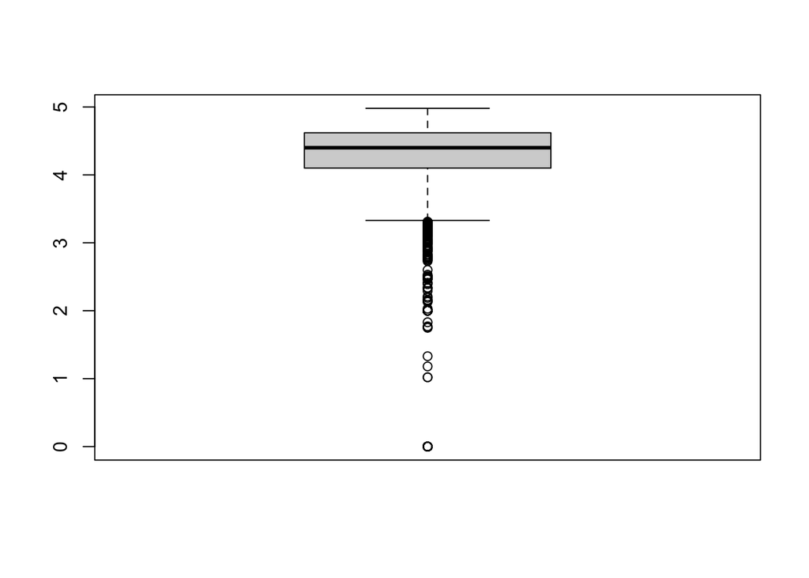

```r
# Checking outlier in avg.review
boxplot(salesdata$avg.review)
```

```r
salesdata %>% filter (avg.review < 3)
```

```
##                                  sold.by publisher.type       genre avg.review daily.sales
## 1         Amazon Digital Services,  Inc.   small/medium non_fiction       2.90       65.13
## 2                Penguin Group (USA) LLC       big five   childrens       2.50       30.01
## 3                Penguin Group (USA) LLC       big five   childrens       2.48       66.83
## 4         Amazon Digital Services,  Inc.          indie non_fiction       2.00       93.09
## 5   Simon and Schuster Digital Sales Inc       big five   childrens       2.48       71.26
## 6         Amazon Digital Services,  Inc.  single author non_fiction       2.00       54.51
## 7         Amazon Digital Services,  Inc.   small/medium     fiction       2.48      118.29
## 8         Amazon Digital Services,  Inc.   small/medium   childrens       2.00       37.40
## 9   Simon and Schuster Digital Sales Inc       big five     fiction       0.00       95.88
## 10        Amazon Digital Services,  Inc.   small/medium   childrens       2.00       81.58
## 11        Amazon Digital Services,  Inc.   small/medium     fiction       0.00       87.71
## 12        Amazon Digital Services,  Inc.   small/medium   childrens       0.00       63.55
## 13              HarperCollins Publishers       big five non_fiction       2.78       74.41
## 14        Amazon Digital Services,  Inc.          indie     fiction       2.75       92.44
```

[output cut: 321 more lines]

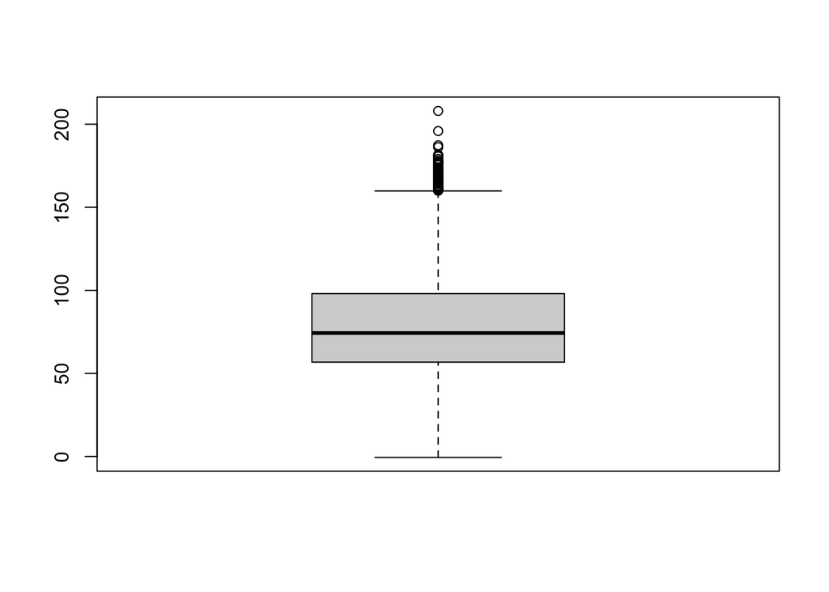

```r
# Result: Data seems normal, the value are possible to be the real value (not input error). Conclusion: Keep all the data.

# Checking outlier in daily.sales
boxplot(salesdata$daily.sales)
```

```r
salesdata %>% filter (daily.sales > 175)
```

```
##                           sold.by publisher.type   genre avg.review daily.sales total.reviews
## 1                       Macmillan       big five fiction       4.31      177.85           174
## 2                Random House LLC       big five fiction       4.62      207.98           196
## 3  Amazon Digital Services,  Inc.  single author fiction       4.70      176.36           174
## 4  Amazon Digital Services,  Inc.          indie fiction       3.80      187.31           202
## 5        HarperCollins Publishers       big five fiction       4.60      180.71           211
## 6  Amazon Digital Services,  Inc.   small/medium fiction       4.10      181.60           185
## 7  Amazon Digital Services,  Inc.  single author fiction       3.91      180.61           190
## 8         Penguin Group (USA) LLC       big five fiction       4.53      176.33           200
## 9  Amazon Digital Services,  Inc.         amazon fiction       4.34      178.87           161
## 10               Random House LLC       big five fiction       4.49      195.89           200
## 11               Random House LLC       big five fiction       4.32      177.07           198
## 12 Amazon Digital Services,  Inc.  single author fiction       4.67      175.49           215
## 13 Amazon Digital Services,  Inc.   small/medium fiction       4.50      179.14           193
## 14 Amazon Digital Services,  Inc.   small/medium fiction       4.61      186.17           195
```

[output cut: 25 more lines]

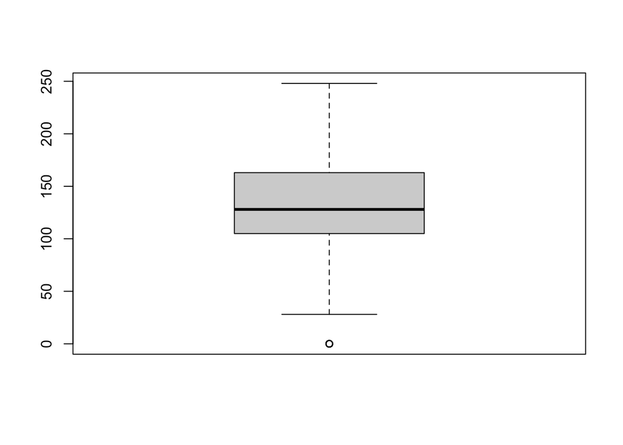

```r
# Result: Data seems normal, the value are possible to be the real value (not input error). Conclusion: Keep all the data.

# Checking outlier in total.reviews
boxplot(salesdata$total.reviews)
```

```r
salesdata %>% filter (total.reviews == 0)
```

```
##                                 sold.by publisher.type       genre avg.review daily.sales
## 1  Simon and Schuster Digital Sales Inc       big five     fiction          0       95.88
## 2        Amazon Digital Services,  Inc.   small/medium     fiction          0       87.71
## 3        Amazon Digital Services,  Inc.   small/medium   childrens          0       63.55
## 4        Amazon Digital Services,  Inc.   small/medium non_fiction          0       72.08
## 5        Amazon Digital Services,  Inc.   small/medium non_fiction          0       66.67
## 6        Amazon Digital Services,  Inc.   small/medium   childrens          0       61.00
## 7        Amazon Digital Services,  Inc.   small/medium     fiction          0       95.20
## 8        Amazon Digital Services,  Inc.          indie non_fiction          0       62.62
## 9        Amazon Digital Services,  Inc.  single author     fiction          0      129.01
## 10                            Macmillan       big five   childrens          0       62.02
## 11       Amazon Digital Services,  Inc.   small/medium     fiction          0       74.20
## 12       Amazon Digital Services,  Inc.          indie   childrens          0       67.09
## 13       Amazon Digital Services,  Inc.          indie     fiction          0       97.06
## 14       Amazon Digital Services,  Inc.  single author non_fiction          0      104.30
```

[output cut: 33 more lines]

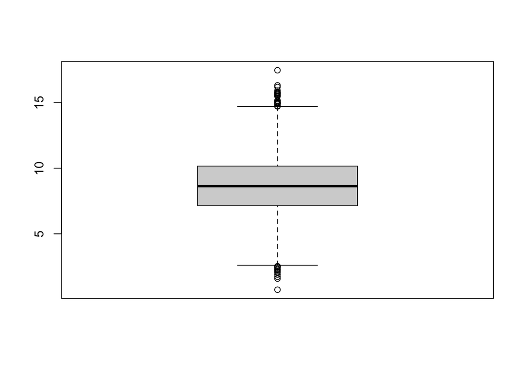

```r
# Result: Data seems normal, the value are possible to be the real value (not input error). Conclusion: Keep all the data.

# Checking outlier in sale.price
boxplot(salesdata$sale.price)
```

```r
salesdata %>% filter (sale.price > 15)
```

```
##                               sold.by publisher.type       genre avg.review daily.sales
## 1  HarperCollins Christian Publishing       big five   childrens       4.61       37.43
## 2      Amazon Digital Services,  Inc.   small/medium   childrens       4.27       41.43
## 3      Amazon Digital Services,  Inc.          indie   childrens       3.85       60.38
## 4      Amazon Digital Services,  Inc.   small/medium   childrens       2.48       19.96
## 5      Amazon Digital Services,  Inc.   small/medium   childrens       3.75       37.60
## 6      Amazon Digital Services,  Inc.   small/medium   childrens       4.19       32.38
## 7      Amazon Digital Services,  Inc.  single author   childrens       4.47       48.68
## 8            HarperCollins Publishers       big five   childrens       4.75       64.41
## 9      Amazon Digital Services,  Inc.   small/medium   childrens       4.72       56.90
## 10     Amazon Digital Services,  Inc.          indie   childrens       4.35       29.16
## 11     Amazon Digital Services,  Inc.   small/medium   childrens       3.97       46.16
## 12     Amazon Digital Services,  Inc.   small/medium non_fiction       3.66       39.10
## 13     Amazon Digital Services,  Inc.   small/medium   childrens       4.39       50.09
## 14     Amazon Digital Services,  Inc.          indie   childrens       4.41       15.37
```

[output cut: 17 more lines]

```r
# Result: Data seems normal, the value are possible to be the real value (not input error). Conclusion: Keep all the data.
```

### 1. Do books from different genres have different daily sales on average?

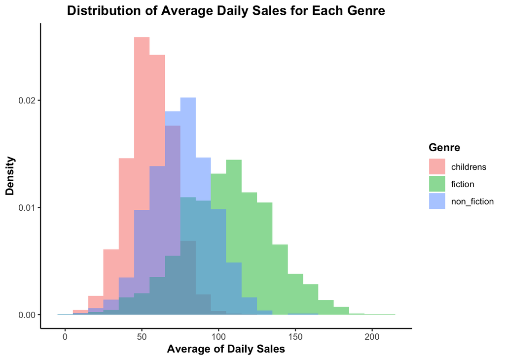

```r
# Plot to see the distribution of average daily sales for each genre
ggplot(salesdata, aes(daily.sales, ..density.., fill=genre))+
  geom_histogram(binwidth=10,position="identity", alpha=0.5)+
  labs(x="Average of Daily Sales", y="Density", fill="Genre")+
  ggtitle("Distribution of Average Daily Sales for Each Genre")+
  theme_classic()+
  theme(plot.title = element_text(hjust = 0.5))+
  theme(title = element_text(face="bold"))
```

```r
# Change the level in genre column to get positive result in mean difference (to be more intuitive)
salesdata$genre <- factor(salesdata$genre, levels = c("fiction", "non_fiction", "childrens"), labels = c("Fiction","Non Fiction", "Children"))

# Create subset data for t-test approach
fiction_childerns <- salesdata %>%
  filter(genre %in% c("Fiction", "Children"))

fiction_nonfiction <- salesdata %>%
  filter(genre %in% c("Fiction", "Non Fiction"))

childrens_nonfiction <- salesdata %>%
  filter(genre %in% c("Children", "Non Fiction"))
```

```r
# Calculate simple statistical summary
salesdata_summary <- salesdata %>%
    group_by(genre) %>%
    dplyr::summarise("Average of Daily Sales" = round(mean(daily.sales, na.rm = TRUE),1),
              "Standard Deviation of Average Daily Sales" = round(sd(daily.sales, na.rm=TRUE),1),
              "Frequency" = n())

# Change column name
colnames(salesdata_summary)[which(names(salesdata_summary) == "genre")] <- "Genre"

salesdata_summary
```

```
## # A tibble: 3 × 4
##   Genre       `Average of Daily Sales` `Standard Deviation of Average Daily Sales` Frequency
##   <fct>                          <dbl>                                       <dbl>     <int>
## 1 Fiction                        106.                                         29.3      2000
## 2 Non Fiction                     75.9                                        20        2000
## 3 Children                        55.6                                        14.9      2000
```

```r
# Two Sample t-test
t.test(daily.sales ~ genre, data = fiction_childerns)
```

```
##
##  Welch Two Sample t-test
##
## data:  daily.sales by genre
## t = 68.401, df = 2962.3, p-value < 2.2e-16
## alternative hypothesis: true difference in means between group Fiction and group Children is not equal to 0
## 95 percent confidence interval:
##  48.86652 51.75078
## sample estimates:
##  mean in group Fiction mean in group Children
##              105.88591               55.57726
```

```r
t.test(daily.sales ~ genre, data = fiction_nonfiction)
```

```
##
##  Welch Two Sample t-test
##
## data:  daily.sales by genre
## t = 37.781, df = 3531.6, p-value < 2.2e-16
## alternative hypothesis: true difference in means between group Fiction and group Non Fiction is not equal to 0
## 95 percent confidence interval:
##  28.46218 31.57796
## sample estimates:
##     mean in group Fiction mean in group Non Fiction
##                 105.88591                  75.86584
```

```r
t.test(daily.sales ~ genre, data = childrens_nonfiction)
```

```
##
##  Welch Two Sample t-test
##
## data:  daily.sales by genre
## t = 36.352, df = 3687.3, p-value < 2.2e-16
## alternative hypothesis: true difference in means between group Non Fiction and group Children is not equal to 0
## 95 percent confidence interval:
##  19.19433 21.38283
## sample estimates:
## mean in group Non Fiction    mean in group Children
##                  75.86584                  55.57726
```

Note that Welch Two Sample t-test is used. P-value obtained from each of the t-test suggest that null hypothesis can be rejected and therefore there are significant differences of average daily sales between each book genre.

```r
# Create a model to predict daily sales by genre
sales_by_genre <- lm(daily.sales ~ genre, data = salesdata)
summary(sales_by_genre)
```

```
##
## Call:
## lm(formula = daily.sales ~ genre, data = salesdata)
##
## Residuals:
##      Min       1Q   Median       3Q      Max
## -102.396  -13.326   -0.076   13.249  102.094
##
## Coefficients:
##                  Estimate Std. Error t value Pr(>|t|)
## (Intercept)      105.8859     0.4973  212.92   <2e-16 ***
## genreNon Fiction -30.0201     0.7033  -42.69   <2e-16 ***
## genreChildren    -50.3086     0.7033  -71.53   <2e-16 ***
## ---
## Signif. codes:  0 '***' 0.001 '**' 0.01 '*' 0.05 '.' 0.1 ' ' 1
##
## Residual standard error: 22.24 on 5997 degrees of freedom
## Multiple R-squared:  0.4635, Adjusted R-squared:  0.4633
## F-statistic:  2590 on 2 and 5997 DF,  p-value: < 2.2e-16
```

```r
# Estimation Approach
(sales_by_genre_emm <- emmeans(sales_by_genre, ~genre))
```

```
##  genre       emmean    SE   df lower.CL upper.CL
##  Fiction      105.9 0.497 5997    104.9    106.9
##  Non Fiction   75.9 0.497 5997     74.9     76.8
##  Children      55.6 0.497 5997     54.6     56.6
##
## Confidence level used: 0.95
```

```r
(sales_by_genre_con <- confint(pairs(sales_by_genre_emm)))
```

```
##  contrast               estimate    SE   df lower.CL upper.CL
##  Fiction - Non Fiction      30.0 0.703 5997     28.4     31.7
##  Fiction - Children         50.3 0.703 5997     48.7     52.0
##  Non Fiction - Children     20.3 0.703 5997     18.6     21.9
##
## Confidence level used: 0.95
## Conf-level adjustment: tukey method for comparing a family of 3 estimates
```

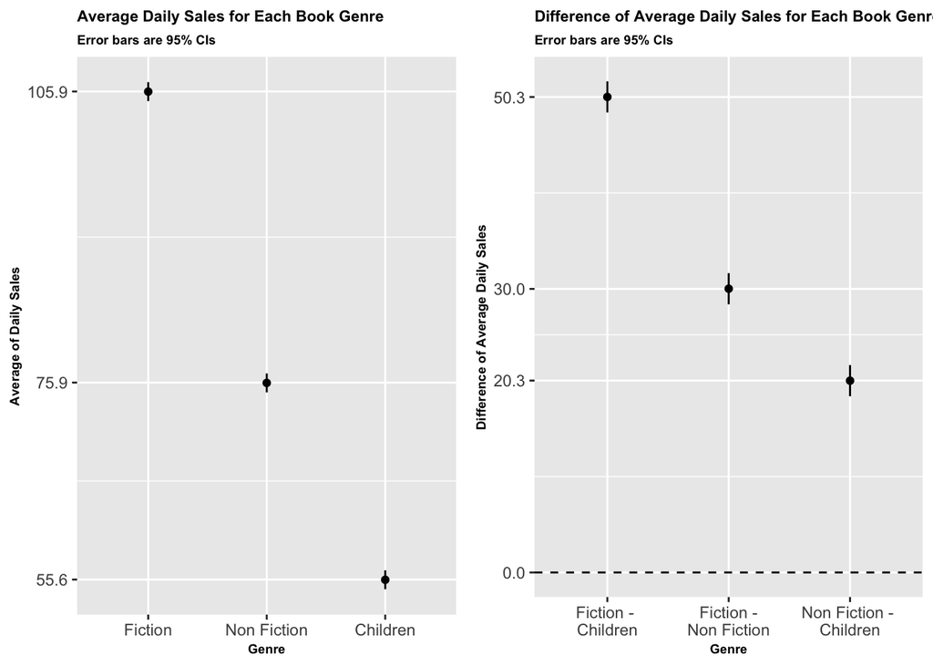

```r
# Estimation of Average Daily Sales for Each Book Genre
estplot <-
  ggplot(summary(sales_by_genre_emm), aes(x=genre, y=emmean, ymin=lower.CL, ymax=upper.CL)) +
  geom_point() +
  geom_linerange() +
  labs(y="Average of Daily Sales", x="Genre", subtitle="Error bars are 95% CIs",
             title="Average Daily Sales for Each Book Genre")+
  scale_y_continuous(breaks = c(105.9, 75.9, 55.6))+
  theme(title = element_text(face="bold", size = 7))

# Difference of Average Daily Sales for Each Book Genre
conplot <-
  ggplot(sales_by_genre_con, aes(x=contrast, y=estimate, ymin=lower.CL, ymax=upper.CL)) +
  geom_point() +
  geom_linerange() +
  labs(y="Difference of Average Daily Sales", x="Genre", subtitle="Error bars are 95% CIs",
       title="Difference of Average Daily Sales for Each Book Genre") +
  scale_y_continuous(breaks = c(50.3, 30, 20.3, 0))+
  geom_hline(yintercept=0, lty=2)+
  theme(title = element_text(face="bold", size = 7)) +
  scale_x_discrete(labels = c("Fiction - \nChildren", "Fiction -\nNon Fiction", "Non Fiction - \nChildren"))

# Arrange both plot into a single plot
grid.arrange(estplot, conplot, ncol = 2)
```

Fiction genre has the highest average daily sales, followed by non fiction and children genre. The average daily sales for genre fiction is $105.9$ $95%$ CI $[104.9-106.9]$. The average daily sales for genre non fiction is $75.9$ $95%$ CI $[74.9-76.8]$. Finally, the average daily sales for genre children is $55.6$ $95%$ CI $[54.6-56.6]$.

The average daily sales of fiction genre is $30$ $95%$ CI $[28.4-31.7]$ and $50.3$ CI $[48.7-52]$ higher compared to non fiction and children genre respectively. Furthermore, the average daily sales of non fiction genre is $20.3$ $95%$ CI $[18.6-21.9]$ higher than children genre.

The estimated difference along with its 95% confidence interval indicates that we can be sure that there is a difference in average daily sales between each genre. The fact that the lower bound of the confidence interval of the graph on the right does not intersect $y = 0$ line means that with 95% CI, the mean difference of average daily sales for each book genre is not equal to zero but rather falls in between its respective 95% confidence interval.

### 2. Do books have more/fewer sales depending upon their average review scores and total number of reviews.

```r
# Create a model to predict daily sales by average review score
sales_by_score <- lm(daily.sales ~ avg.review, salesdata)
summary(sales_by_score)
```

```
##
## Call:
## lm(formula = daily.sales ~ avg.review, data = salesdata)
##
## Residuals:
##     Min      1Q  Median      3Q     Max
## -79.944 -22.299  -4.837  18.943 128.948
##
## Coefficients:
##             Estimate Std. Error t value Pr(>|t|)
## (Intercept)  80.0517     2.9510  27.127   <2e-16 ***
## avg.review   -0.2208     0.6854  -0.322    0.747
## ---
## Signif. codes:  0 '***' 0.001 '**' 0.01 '*' 0.05 '.' 0.1 ' ' 1
##
## Residual standard error: 30.36 on 5998 degrees of freedom
## Multiple R-squared:  1.729e-05,  Adjusted R-squared:  -0.0001494
## F-statistic: 0.1037 on 1 and 5998 DF,  p-value: 0.7474
```

```r
cbind(coefficient=coef(sales_by_score), confint(sales_by_score))
```

```
##             coefficient     2.5 %    97.5 %
## (Intercept)  80.0516716 74.266706 85.836637
## avg.review   -0.2207529 -1.564417  1.122911
```

```r
anova(sales_by_score)
```

```
## Analysis of Variance Table
##
## Response: daily.sales
##              Df  Sum Sq Mean Sq F value Pr(>F)
## avg.review    1      96   95.61  0.1037 0.7474
## Residuals  5998 5528565  921.73
```

```r
# Create a model to predict daily sales by total number of review
sales_by_totalreview <- lm(daily.sales ~ total.reviews, salesdata)
summary(sales_by_totalreview)
```

```
##
## Call:
## lm(formula = daily.sales ~ total.reviews, data = salesdata)
##
## Residuals:
##      Min       1Q   Median       3Q      Max
## -103.202  -14.824   -1.026   13.620  138.424
##
## Coefficients:
##               Estimate Std. Error t value Pr(>|t|)
## (Intercept)   7.875622   1.077639   7.308 3.06e-13 ***
## total.reviews 0.537048   0.007818  68.694  < 2e-16 ***
## ---
## Signif. codes:  0 '***' 0.001 '**' 0.01 '*' 0.05 '.' 0.1 ' ' 1
##
## Residual standard error: 22.71 on 5998 degrees of freedom
## Multiple R-squared:  0.4403, Adjusted R-squared:  0.4402
## F-statistic:  4719 on 1 and 5998 DF,  p-value: < 2.2e-16
```

```r
cbind(coefficient=coef(sales_by_totalreview), confint(sales_by_totalreview))
```

```
##               coefficient     2.5 %    97.5 %
## (Intercept)      7.875622 5.7630625 9.9881824
## total.reviews    0.537048 0.5217219 0.5523741
```

```r
anova(sales_by_totalreview)
```

```
## Analysis of Variance Table
##
## Response: daily.sales
##                 Df  Sum Sq Mean Sq F value    Pr(>F)
## total.reviews    1 2434381 2434381  4718.8 < 2.2e-16 ***
## Residuals     5998 3094279     516
## ---
## Signif. codes:  0 '***' 0.001 '**' 0.01 '*' 0.05 '.' 0.1 ' ' 1
```

```r
# Predict total sales by average review scores and total number of review
sales_by_score_totalreview <- lm(daily.sales ~ avg.review + total.reviews, salesdata)
summary(sales_by_score_totalreview)
```

```
##
## Call:
## lm(formula = daily.sales ~ avg.review + total.reviews, data = salesdata)
##
## Residuals:
##      Min       1Q   Median       3Q      Max
## -103.396  -14.645   -1.059   13.690  122.429
##
## Coefficients:
##                Estimate Std. Error t value Pr(>|t|)
## (Intercept)   23.870506   2.341271  10.196  < 2e-16 ***
## avg.review    -3.943548   0.513120  -7.685 1.77e-14 ***
## total.reviews  0.543329   0.007823  69.451  < 2e-16 ***
## ---
## Signif. codes:  0 '***' 0.001 '**' 0.01 '*' 0.05 '.' 0.1 ' ' 1
##
## Residual standard error: 22.6 on 5997 degrees of freedom
## Multiple R-squared:  0.4458, Adjusted R-squared:  0.4456
## F-statistic:  2412 on 2 and 5997 DF,  p-value: < 2.2e-16
```

```r
cbind(coefficient=coef(sales_by_score_totalreview), confint(sales_by_score_totalreview))
```

```
##               coefficient      2.5 %     97.5 %
## (Intercept)     23.870506 19.2807719 28.4602399
## avg.review      -3.943548 -4.9494480 -2.9376473
## total.reviews    0.543329  0.5279926  0.5586653
```

```r
anova(sales_by_score_totalreview)
```

```
## Analysis of Variance Table
##
## Response: daily.sales
##                 Df  Sum Sq Mean Sq   F value Pr(>F)
## avg.review       1      96      96    0.1871 0.6653
## total.reviews    1 2464464 2464464 4823.4038 <2e-16 ***
## Residuals     5997 3064100     511
## ---
## Signif. codes:  0 '***' 0.001 '**' 0.01 '*' 0.05 '.' 0.1 ' ' 1
```

```r
# Check multicolinearity between the predictors
vif(sales_by_score_totalreview)
```

```
##    avg.review total.reviews
##      1.011033      1.011033
```

Both Variance Inflation Factor (VIF) scores are less then 5. It means that it is justified to keep both variable as the predictors for our model.

```r
# Examine model with interaction terms
sales_by_score_totalreview_int <- lm(daily.sales ~total.reviews * avg.review, salesdata)
summary(sales_by_score_totalreview_int)
```

```
##
## Call:
## lm(formula = daily.sales ~ total.reviews * avg.review, data = salesdata)
##
## Residuals:
##     Min      1Q  Median      3Q     Max
## -104.08  -14.63   -0.92   13.82   92.33
##
## Coefficients:
##                            Estimate Std. Error t value Pr(>|t|)
## (Intercept)               63.546900   4.178047  15.210  < 2e-16 ***
## total.reviews              0.164754   0.034068   4.836 1.36e-06 ***
## avg.review               -13.683765   0.993159 -13.778  < 2e-16 ***
## total.reviews:avg.review   0.091688   0.008035  11.411  < 2e-16 ***
## ---
## Signif. codes:  0 '***' 0.001 '**' 0.01 '*' 0.05 '.' 0.1 ' ' 1
##
## Residual standard error: 22.36 on 5996 degrees of freedom
## Multiple R-squared:  0.4576, Adjusted R-squared:  0.4573
## F-statistic:  1686 on 3 and 5996 DF,  p-value: < 2.2e-16
```

```r
cbind(coefficient=coef(sales_by_score_totalreview_int), confint(sales_by_score_totalreview_int))
```

```
##                           coefficient        2.5 %      97.5 %
## (Intercept)               63.54690004  55.35642562  71.7373745
## total.reviews              0.16475390   0.09796872   0.2315391
## avg.review               -13.68376484 -15.63071313 -11.7368165
## total.reviews:avg.review   0.09168842   0.07593650   0.1074403
```

```r
anova(sales_by_score_totalreview_int)
```

```
## Analysis of Variance Table
##
## Response: daily.sales
##                            Df  Sum Sq Mean Sq  F value    Pr(>F)
## total.reviews               1 2434381 2434381 4867.178 < 2.2e-16 ***
## avg.review                  1   30179   30179   60.338 9.334e-15 ***
## total.reviews:avg.review    1   65125   65125  130.207 < 2.2e-16 ***
## Residuals                5996 2998976     500
## ---
## Signif. codes:  0 '***' 0.001 '**' 0.01 '*' 0.05 '.' 0.1 ' ' 1
```

```r
# Compare model with only main effect and the model with interaction terms
anova(sales_by_score_totalreview, sales_by_score_totalreview_int)
```

```
## Analysis of Variance Table
##
## Model 1: daily.sales ~ avg.review + total.reviews
## Model 2: daily.sales ~ total.reviews * avg.review
##   Res.Df     RSS Df Sum of Sq      F    Pr(>F)
## 1   5997 3064100
## 2   5996 2998976  1     65125 130.21 < 2.2e-16 ***
## ---
## Signif. codes:  0 '***' 0.001 '**' 0.01 '*' 0.05 '.' 0.1 ' ' 1
```

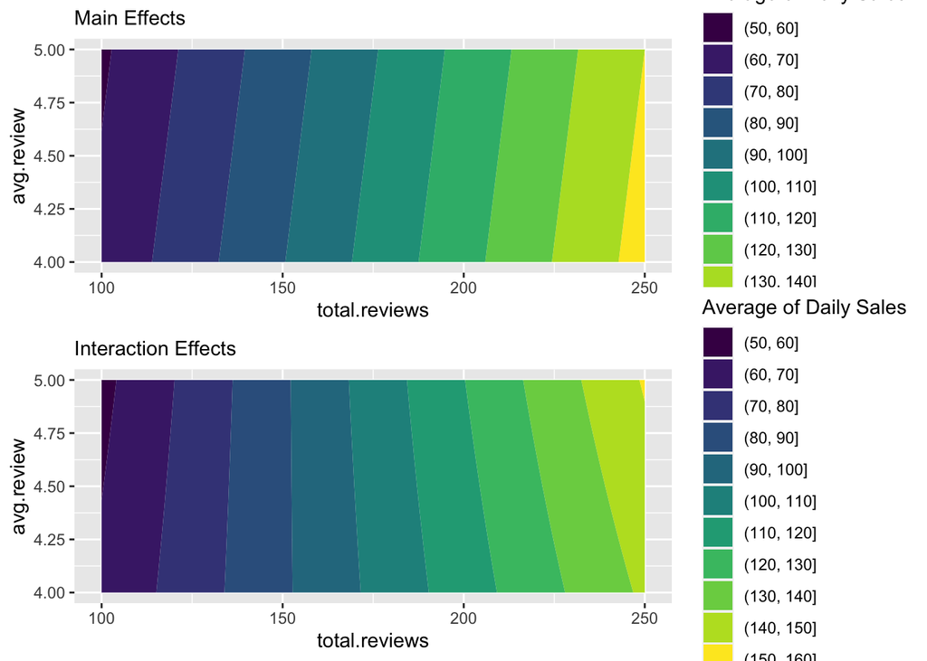

```r
# Visualisation of base model and model with interactions
surf_data <- tibble(total.reviews = unlist(expand.grid(seq(100, 250 , 25), seq(4, 5, 0.1))[1]),
                         avg.review = unlist(expand.grid(seq(100, 250, 25), seq(4, 5, 0.1))[2]))

surf_data <- mutate(surf_data,
                         main_hat = predict(sales_by_score_totalreview, surf_data),
                         intr_hat = predict(sales_by_score_totalreview_int, surf_data))

surf_main <- ggplot(surf_data, aes(total.reviews, avg.review)) + geom_contour_filled(aes(z = main_hat)) + labs(subtitle = "Main Effects")  + guides(fill=guide_legend(title="Average of Daily Sales"))
surf_intr <- ggplot(surf_data, aes(total.reviews, avg.review)) + geom_contour_filled(aes(z = intr_hat)) + labs(subtitle = "Interaction Effects")   + guides(fill=guide_legend(title="Average of Daily Sales"))
grid.arrange(surf_main, surf_intr, nrow = 2)
```

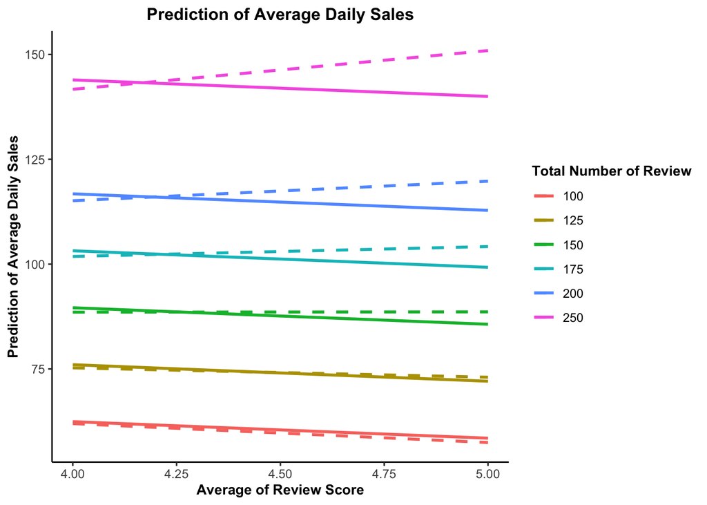

```r
# Create a plot to visualize the effect of interaction terms

score_review <- filter(surf_data, total.reviews %in% c(100, 125, 150, 175, 200, 200, 250)) %>%
  mutate(total.reviews = factor(total.reviews))
(
  predplot<-
  ggplot(score_review) +
  geom_line(aes(avg.review, main_hat, colour = total.reviews), size = 1) +
  geom_line(aes(avg.review, intr_hat, colour = total.reviews), linetype = "dashed", size = 1) +
  labs(x = "Average of Review Score", y = "Prediction of Average Daily Sales")+
  ggtitle("Prediction of Average Daily Sales")+
  theme_classic()+
  theme(plot.title = element_text(hjust = 0.5))+
  theme(title = element_text(face="bold"))+
  theme(title = element_text(face="bold", size = 10)) +
  guides(colour=guide_legend(title="Total Number of Review"))
)
```

In the main effects model, the slope of average of review score against average of daily sales is always parallel for all different values of total number of review.

In the interaction model, the slope of average of review score against average of daily sales are different with different values of total number of review. With low number of review (< 150 review), the slope of average of review score against average of daily sales is negative. However, the more the review, the slope of average of review score against average of daily sales shifts to have steeper positive gradient.

### 3. What is the effect of sale price upon the number of sales, and is this different across genres?

```r
# Create a model to predict average daily sales by average sale price
sales_by_price <- lm(daily.sales~sale.price, salesdata)
summary(sales_by_price)
```

```
##
## Call:
## lm(formula = daily.sales ~ sale.price, data = salesdata)
##
## Residuals:
##     Min      1Q  Median      3Q     Max
## -80.769 -20.650  -4.633  17.099 130.315
##
## Coefficients:
##             Estimate Std. Error t value Pr(>|t|)
## (Intercept) 112.0820     1.5207   73.70   <2e-16 ***
## sale.price   -3.8156     0.1705  -22.38   <2e-16 ***
## ---
## Signif. codes:  0 '***' 0.001 '**' 0.01 '*' 0.05 '.' 0.1 ' ' 1
##
## Residual standard error: 29.17 on 5998 degrees of freedom
## Multiple R-squared:  0.07706,    Adjusted R-squared:  0.07691
## F-statistic: 500.8 on 1 and 5998 DF,  p-value: < 2.2e-16
```

```r
cbind(coefficient=coef(sales_by_price), confint(sales_by_price))
```

```
##             coefficient      2.5 %     97.5 %
## (Intercept)  112.081955 109.100803 115.063107
## sale.price    -3.815615  -4.149857  -3.481374
```

```r
anova(sales_by_price)
```

```
## Analysis of Variance Table
##
## Response: daily.sales
##              Df  Sum Sq Mean Sq F value    Pr(>F)
## sale.price    1  426054  426054  500.82 < 2.2e-16 ***
## Residuals  5998 5102606     851
## ---
## Signif. codes:  0 '***' 0.001 '**' 0.01 '*' 0.05 '.' 0.1 ' ' 1
```

```r
# Estimation Approach
( sales_by_price_emm <- emmeans(sales_by_price, ~sale.price, at=list(sale.price=c(1, 5, 9, 13, 17))))
```

```
##  sale.price emmean    SE   df lower.CL upper.CL
##           1  108.3 1.356 5998    105.6    110.9
##           5   93.0 0.726 5998     91.6     94.4
##           9   77.7 0.381 5998     77.0     78.5
##          13   62.5 0.833 5998     60.8     64.1
##          17   47.2 1.474 5998     44.3     50.1
##
## Confidence level used: 0.95
```

```r
# Create a model to predict average daily sales by genre and sale price (with only main effect)
sales_by_price_genre <- lm(daily.sales~sale.price+genre, salesdata)
summary(sales_by_price_genre)
```

```
##
## Call:
## lm(formula = daily.sales ~ sale.price + genre, data = salesdata)
##
## Residuals:
##      Min       1Q   Median       3Q      Max
## -102.357  -13.311    0.031   13.097  102.924
##
## Coefficients:
##                  Estimate Std. Error t value Pr(>|t|)
## (Intercept)      112.5644     1.2556   89.65  < 2e-16 ***
## sale.price        -0.8324     0.1438   -5.79  7.4e-09 ***
## genreNon Fiction -30.1126     0.7016  -42.92  < 2e-16 ***
## genreChildren    -48.6713     0.7562  -64.36  < 2e-16 ***
## ---
## Signif. codes:  0 '***' 0.001 '**' 0.01 '*' 0.05 '.' 0.1 ' ' 1
##
## Residual standard error: 22.18 on 5996 degrees of freedom
## Multiple R-squared:  0.4665, Adjusted R-squared:  0.4662
## F-statistic:  1748 on 3 and 5996 DF,  p-value: < 2.2e-16
```

```r
cbind(coefficient=coef(sales_by_price_genre), confint(sales_by_price_genre))
```

```
##                  coefficient      2.5 %      97.5 %
## (Intercept)      112.5643900 110.102988 115.0257921
## sale.price        -0.8324344  -1.114286  -0.5505827
## genreNon Fiction -30.1126117 -31.487927 -28.7372962
## genreChildren    -48.6713347 -50.153847 -47.1888227
```

```r
anova(sales_by_price_genre)
```

```
## Analysis of Variance Table
##
## Response: daily.sales
##              Df  Sum Sq Mean Sq F value    Pr(>F)
## sale.price    1  426054  426054  866.08 < 2.2e-16 ***
## genre         2 2152964 1076482 2188.26 < 2.2e-16 ***
## Residuals  5996 2949642     492
## ---
## Signif. codes:  0 '***' 0.001 '**' 0.01 '*' 0.05 '.' 0.1 ' ' 1
```

```r
# Create a model to predict average daily sales by genre and sale price (with interaction terms)
sales_by_price_genre_int <- lm(daily.sales~sale.price*genre, salesdata)
summary(sales_by_price_genre_int)
```

```
##
## Call:
## lm(formula = daily.sales ~ sale.price * genre, data = salesdata)
##
## Residuals:
##     Min      1Q  Median      3Q     Max
## -102.38  -13.37    0.03   13.08  102.37
##
## Coefficients:
##                             Estimate Std. Error t value Pr(>|t|)
## (Intercept)                 108.0774     2.1110  51.197  < 2e-16 ***
## sale.price                   -0.2732     0.2558  -1.068    0.286
## genreNon Fiction            -28.6500     2.9085  -9.851  < 2e-16 ***
## genreChildren               -35.1993     3.2740 -10.751  < 2e-16 ***
## sale.price:genreNon Fiction  -0.1770     0.3542  -0.500    0.617
## sale.price:genreChildren     -1.4587     0.3546  -4.114 3.94e-05 ***
## ---
## Signif. codes:  0 '***' 0.001 '**' 0.01 '*' 0.05 '.' 0.1 ' ' 1
##
## Residual standard error: 22.15 on 5994 degrees of freedom
## Multiple R-squared:  0.4683, Adjusted R-squared:  0.4679
## F-statistic:  1056 on 5 and 5994 DF,  p-value: < 2.2e-16
```

```r
cbind(coefficient=coef(sales_by_price_genre_int), confint(sales_by_price_genre_int))
```

```
##                             coefficient       2.5 %      97.5 %
## (Intercept)                 108.0773903 103.9390903 112.2156903
## sale.price                   -0.2731555  -0.7745789   0.2282679
## genreNon Fiction            -28.6500267 -34.3516874 -22.9483659
## genreChildren               -35.1992729 -41.6174666 -28.7810791
## sale.price:genreNon Fiction  -0.1770058  -0.8713648   0.5173531
## sale.price:genreChildren     -1.4587088  -2.1538022  -0.7636155
```

```r
anova(sales_by_price_genre_int)
```

```
## Analysis of Variance Table
##
## Response: daily.sales
##                    Df  Sum Sq Mean Sq  F value    Pr(>F)
## sale.price          1  426054  426054  868.770 < 2.2e-16 ***
## genre               2 2152964 1076482 2195.060 < 2.2e-16 ***
## sale.price:genre    2   10118    5059   10.316  3.37e-05 ***
## Residuals        5994 2939524     490
## ---
## Signif. codes:  0 '***' 0.001 '**' 0.01 '*' 0.05 '.' 0.1 ' ' 1
```

The effect of genre varies significantly over sale price, $F(2, 5994)=10.32$, $p < 0.0001$.

```r
# Compare the model with only main effect and with the model with interaction terms
anova(sales_by_price, sales_by_price_genre_int)
```

```
## Analysis of Variance Table
##
## Model 1: daily.sales ~ sale.price
## Model 2: daily.sales ~ sale.price * genre
##   Res.Df     RSS Df Sum of Sq      F    Pr(>F)
## 1   5998 5102606
## 2   5994 2939524  4   2163082 1102.7 < 2.2e-16 ***
## ---
## Signif. codes:  0 '***' 0.001 '**' 0.01 '*' 0.05 '.' 0.1 ' ' 1
```

```r
# Estimate the value of average daily sales
( sales_by_price_genre_int_emm <- emmeans(sales_by_price_genre_int, ~sale.price+genre, at=list(sale.price=c(1, 5, 9, 13, 17))))
```

```
##  sale.price genre       emmean    SE   df lower.CL upper.CL
##           1 Fiction      107.8 1.863 5994    104.2    111.5
##           5 Fiction      106.7 0.918 5994    104.9    108.5
##           9 Fiction      105.6 0.555 5994    104.5    106.7
##          13 Fiction      104.5 1.366 5994    101.8    107.2
##          17 Fiction      103.4 2.349 5994     98.8    108.0
##           1 Non Fiction   79.0 1.764 5994     75.5     82.4
##           5 Non Fiction   77.2 0.868 5994     75.5     78.9
##           9 Non Fiction   75.4 0.562 5994     74.3     76.5
##          13 Non Fiction   73.6 1.341 5994     70.9     76.2
##          17 Non Fiction   71.8 2.281 5994     67.3     76.2
##           1 Children      71.1 2.262 5994     66.7     75.6
##           5 Children      64.2 1.322 5994     61.6     66.8
##           9 Children      57.3 0.552 5994     56.2     58.4
##          13 Children      50.4 0.890 5994     48.6     52.1
##          17 Children      43.4 1.791 5994     39.9     46.9
##
## Confidence level used: 0.95
```

```r
# Combine model with only sale price with the model with sale price and genre
both_models_emms <- bind_rows(list(data.frame(sales_by_price_emm, Model="Only Sale Price"), data.frame(sales_by_price_genre_int_emm, Model="Sale Price and Genre")))

both_models_emms$genre <- as.character(both_models_emms$genre)

both_models_emms[is.na(both_models_emms)] = "Overall"

both_models_emms$genre <- as.factor(both_models_emms$genre)

both_models_emms$genre
```

```
##  [1] Overall     Overall     Overall     Overall     Overall     Fiction     Fiction     Fiction
##  [9] Fiction     Fiction     Non Fiction Non Fiction Non Fiction Non Fiction Non Fiction Children
## [17] Children    Children    Children    Children
## Levels: Children Fiction Non Fiction Overall
```

```r
# Create a plot to visualize the effect of sale price to average daily sale in each genre
bothplot <-
  ggplot(both_models_emms, aes(x=sale.price, y=emmean, ymin=lower.CL, ymax=upper.CL, col=genre)) +
  geom_line(aes(x=sale.price, y= emmean, lty = Model)) +
  geom_ribbon(aes(ymin = lower.CL, ymax = upper.CL, col = genre), alpha = 0.1)+
  labs(x="Sale Price (£)", y="Average of Daily Sales", col="Genre", subtitle="Error bars are 95% CIs")+
  ggtitle("Effect of Sale Price and Genre to Average Daily Sales")+
  scale_x_continuous(breaks = c(1, 5, 9, 13, 17))+
  scale_y_continuous(breaks = c(30, 60, 90, 120))+
  theme_classic()+
  theme(plot.title = element_text(hjust = 0))+
  theme(title = element_text(face="bold"))+
  theme(title = element_text(face="bold", size = 10))
```

## Section 2

### Introduction

This report will focus on examining the effect of genre, average of review score, total number of review, and average sales price on the average of daily sales.

### 1. Relationship between Average Daily Sales and Genre

The average of daily sales for each book genre (fiction, non fiction, and children) are compared to see whether the books from different genres have different average of daily sales.

A table comparing the average of daily sales for each genre is prepared below.

Table 1. Average of Daily Sales for Each Book Genre

| Genre | Average of Daily Sales | Standard Deviation of Average Daily Sales | Frequency |
| --- | --- | --- | --- |
| Fiction | 105.9 | 29.3 | 2000 |
| Non Fiction | 75.9 | 20.0 | 2000 |
| Children | 55.6 | 14.9 | 2000 |

Based on the result above, Null Hypothesis Significance Testing (NHST) and Estimation Approach are used to test the significance of the difference between the average of daily sales for each book genre.

**Null Hypothesis Significance Testing (NHST)**

In NHST method, t-test is used. A t-test is a statistical test that compares the means of two samples. In a two sample t-test, the null hypothesis is the means difference between two samples equal to zero. On the opposite, the alternate hypothesis is that the means difference between two sample is not equal to zero.

The result of the t-test shows that the $p-value$ is less then $0.005$ ($p-value < 0.005$), therefore Null Hypothesis can be rejected. It can be concluded that there is a significant difference in average daily sales between fiction $(Mean = 105.9, SD = 29.3)$, non fiction $(Mean = 75.9, SD = 20)$ and children $(Mean = 55.6, SD = 14.9)$ genre.

**Estimation Approach**

Rather than using one value to determine the significance difference of two means, estimation method introduce the concept of Confidence Interval (CI) to supplement the point estimate (in this case average of daily sales) with information about the uncertainty in this estimate.

After performing estimation approach, the result is obtained. Fiction genre has the highest average daily sales, followed by non fiction and children genre. The average daily sales for genre fiction is $105.9$ $95%$ CI $[104.9-106.9]$. The average daily sales for genre non fiction is $75.9$ $95%$ CI $[74.9-76.8]$. Finally, the average daily sales for genre childrens is $55.6$ $95%$ CI $[54.6-56.6]$.

The average daily sales of fiction genre is $30$ $95%$ CI $[28.4-31.7]$ and $50.3$ CI $[48.7-52]$ higher compared to non fiction and children genre respectively. Furthermore, the average daily sales of non fiction genre is $20.3$ $95%$ CI $[18.6-21.9]$ higher than children genre.

The result can be incorporated in a graph as follow.

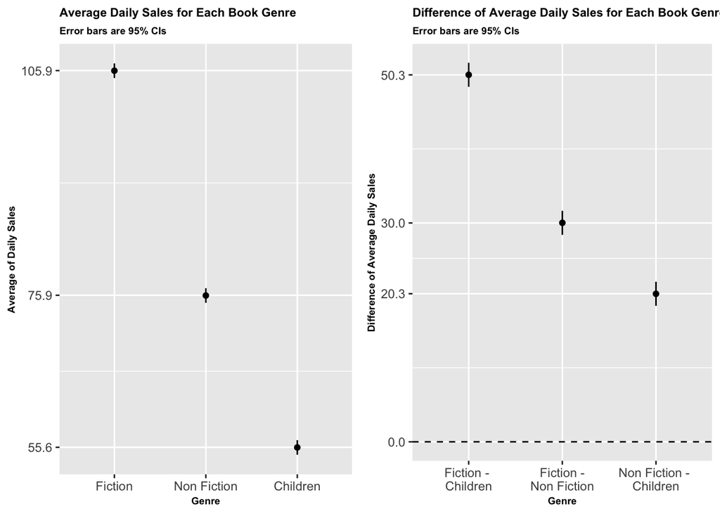

**Figure 1. Estimation of Average Daily Sales for Each Book Genre**

The estimated difference along with its 95% confidence interval indicates that we can be sure that there is a difference in average daily sales between each genre. The fact that the lower bound of the confidence interval of the graph on the right does not intersect $y = 0$ line means that with 95% CI, the mean difference of average daily sales for each book genre is not equal to zero but rather falls in between its respective 95% confidence interval.

### 2.Effect of Average of Review Score and Total Number of Reviews On Average Daily Sales

Before examining the effect of average of review score and total number of review on average daily sales, simple linear models were built to understand whether Average Review Score or Total Number of Review is a significant predictor for Average Daily Sales. The models show that that relationship between average daily sales and average review score is not significant in a linear model $t(5998)=−0.32, p=0.75$. On the contrary, the results suggest that there is a significant average increase of $0.54$ average daily sales for every $1$ increase of total number of review $t(5998)=68.69, p<0.0001$. Therefore, the relationship between average daily sales and total number of review is significant in a linear model.

To examine the effect of average review score and total number of review to average of book sales, two (2) linear models are examined. Those model are:

**a. Main Model**

In this model, both predictors (average of review score and total number of review) are used to predict average of daily sales.

In the model involving both predictors, the average of daily sales increases by a statistically significant $0.54$, $t(5997) = 69.45, p<.0001$, for every extra review, holding the average of review score constant.

Similarly, the average of daily sales decreases by a statistically significant $3.94$, $t(5997)= -7.69, p<.0001$, for every increase of average review score by $1$ point, holding the number of total reviews constant.

It is interesting to note that the average of review score become a significant predictor of average of daily sales when the effect of total review is held constant, but not when average of review score is the only predictor.

**b. Interaction Model**

In this model, both predictors (average of review score and total number of review) are used to predict average of daily sales. On top of that, interaction term between both prediction is also considered in the model.

The result shows that there is a significant positive interaction $(t(5996) = 11.41, p < 0.001)$ between total number of review and average score of the review when predicting average of daily sales. This means that when the value of total review is higher, the slope of average of review score is steeper.

With anova test, it is concluded that adding interaction terms between main effect (average of review score and total number of review) significantly improves the overall model fit compared to the main model, in which only main effect of both predictors are considered $F(1,5996)= 130.21, p < .0001$.

Interaction Model has the best overall model fit to predict average of daily sales. Therefore, the model is used to explain the relationship between dependent variable (average of daily sales) and independent variables (average of review score and total number of review). To illustrate the relationship, a graph is prepared below.

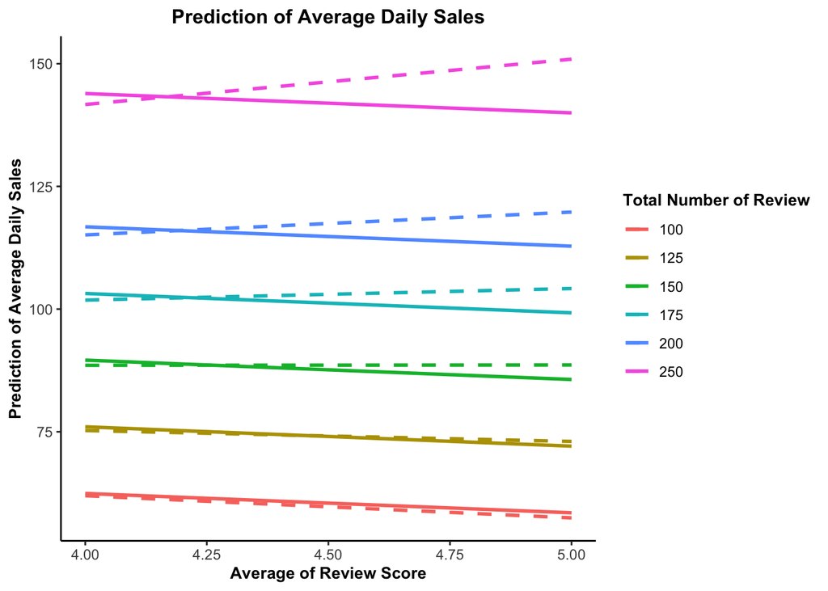

**Figure 2. Prediction of Average Daily Sales from Average Review Score and Total Review**

In **Figure 2.** above, solid line represent the prediction result from main model while the dashed line represent the prediction from the interaction model.

In the main model, the slope of average of review score against average of daily sales is always parallel for all different values of total number of review. It means that high average of review score always negatively impact the average of daily sales. The higher the average of review score, the lower the average of daily sales.

In the interaction model, the slope of average of review score against average of daily sales are different with different values of total number of review. With low number of review (< 150 reviews), the slope of average of review score against average of daily sales is negative. It means that The higher the average of review score, the lower the average of daily sales. However, the more the total number of review, the slope of average of review score against average of daily sales shifts to have steeper positive gradient. With high number of review (> 175 reviews), higher average of review score will lead to higher average of daily sales.

### 3. Effect of Sale Price On The Number of Overall Sales and Across Book Genres

**b. Effect of Sale Price On The Number of Sales for Different Genres**

Two check whether the effect of sale price on the number of sales differ across different genres, the variable genre is introduced to the model. On top of that, interaction term between both prediction is also considered in the model.

With anova test, it is concluded that adding genre as independent variable, along with interaction terms between genre and average of sale price significantly improves the overall model fit compared to the base model, in which only average of sale price is considered as the independent variable $F(4,5994)= 1102.7, p < .0001$.

To better illustrate the effect of average sale price and genre to the average of daily sales, a figure is prepared below.

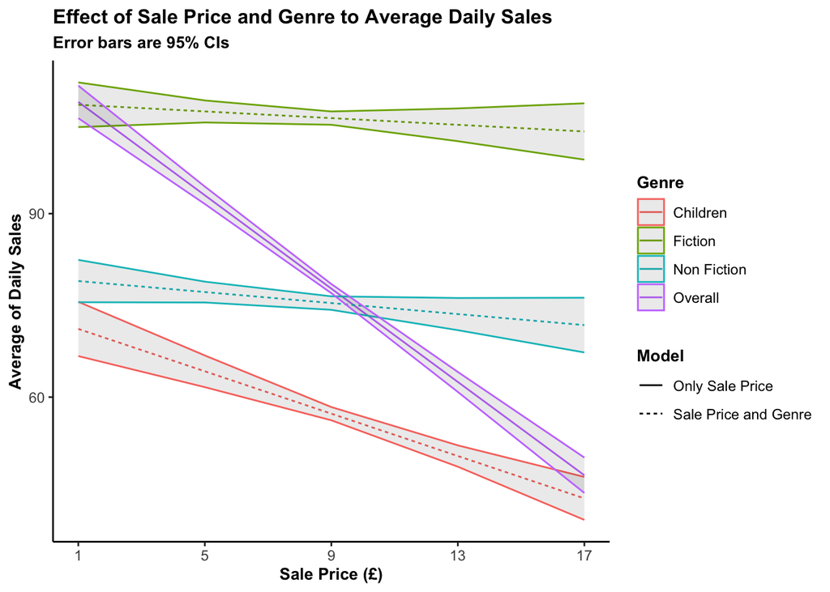

**Figure 3. Effect of Sale Price and Genre to Average Daily Sales**

In general, an increase on the sale price will reduce the average of daily sales. The trend applies to overall sale (represented by solid, purple line) and sale for each genre (represented by dashed line). The grey shade represents the 95% confidence interval for each genre and overall data.

However, further analysis shows that the effect of sale price is significantly differ across genre. As **Figure 3.** suggests, children genre is the most price sensitive among the other genres, indicated by a steep negative slope (red, dashed line). It means with the same increase of sale price, the sale of children genre will drop more than two other genres.